# Technical Report: Full House Modeling for rankings of historical figures

Elisha Cohen, Adrian Burgos Jr., Shen Yan, and Daniel J. Eck

In this technical report we go through the steps that we took to rank historical figures via an era-neutral version of the Historical Popularity Index (HPI) in [Yu et al (2016)](https://www.nature.com/articles/sdata201575) obtained via Full House Modeling. This technical report is reproducible by anyone who has the fullhouse package and our data sets. Long code chunks that create plots will be suppressed. Code for these plots is available in the accompanying .Rmd file. This report will cover the following topics:

# List of Topics

- Data Preparation: Data preprocessing steps and software
- Historical Eras: Definition of eras used to construct the eligible population of historic figures
  - Eras Defined by Centuries: ie, all eligible people born during 1700-1799
  - Eras Defined as Separate Chapters in a History Course: ie, all eligible people born during the Emergence of the First Global Age, 1450-1770 CE
- Full House Modeling: Definition, implementation, diagnostics, and results of Full House Modeling
  - Eras Defined by Centuries: Full House Modeling when eras are defined by centuries
  - Eras Defined as Separate Chapters in a History Course: Full House Modeling when eras are defined by chapters in a history course
- Comparison of Approaches: Comparison of rankings obtained from HPI and versions of era-adjusted HPI
- Interesting Changes in Rankings: Additional interesting rankings changes between HPI and versions of era-adjusted HPI
  - Eras Defined as Centuries: Interesting changes in rankings when switching from HPI to era-adjusted HPI with eras defined by centuries
  - Eras Defined as Separate Chapters in a History Course: Interesting changes in rankings when switching from HPI to era-adjusted HPI with eras defined by chapters in a history course
- Sensitivity in Eligible Population: Investigations into the sensitivity of the eligible population when eras are defined by centuries
  - Linear Increase in Eligible Population: Eligible population increases linearly
  - Flat Increase in Eligible Population: Eligible population increases linearly but is mostly flat

# Data Preparation

Population data collection is through 05/17/2022. The Pantheon data used is the [2020 Person Dataset version 2.0](https://pantheon.world/data/datasets). We load in the following software packages:

```r
library(tidyverse)
library(parallel)
library(orderstats)
library(Pareto)
library(doParallel)
library(kableExtra)
library(fullhouse)

# get number of cores
nCores = detectCores() - 2
nCores
```

```
## [1] 8
```

We load in the data sets used in this analysis:

```r
## estimate of historical eligible population
dat_HPI_eligible = read_csv("dat_HPI_eligible.csv")
## Pantheon data
persons2020 = read_csv("person_2020_update.csv")
```

We remove duplicates of bios with a common name and birth year.

```r
persons2020 =
  persons2020 %>% distinct(name, birthyear, .keep_all = TRUE)
```

We change Donald Trump’s 2020 HPI value of 94.9 to his 2022 HPI value of 78.13. Our aim is to study the most impactful people in history. We do not think it proper to conduct our analyses with Donald Trump’s popularity in 2020 when he had fallen 679 spots in two years and is still living at the time of this analysis. While HPI is a proxy measure of impact through popularity, the intention of HPI is to correct recency biases. We felt it best to ignore an active historical figure whose current popularity might not be reflective of their historic popularity.

```r
persons2020 = persons2020 %>%
  mutate(hpi = ifelse(name == "Donald Trump", 78.13, hpi)) %>%
  arrange(desc(hpi))
```

Back to topics

# Historical eras

We now define historical eras. Here the eras constitute a subpopulation of contemporaneous people. People within a common era are viewed as “competing against each other” for large HPI values. Back to topics

## Eras Defined by Centuries

Here we define eras to constitute a relatively narrow range of years. The most recent year in our analysis in 1980. The eras will be defined by the centuries, and we will only consider eras that have at least 50 people in the Pantheon data set. Our first era begins in 800 BC, the second begins in 700 BC, and so on.

We will define Jesus’s and other Christian figures’ birth year to be 0 AD. This is done to separate memorable Christian figures from memorable Roman figures into different peer groups. We moved Jesus instead of Julius Ceasar and other Roman figures because [Jesus’s birth year is not exactly known](https://en.wikipedia.org/wiki/Jesus).

```r
## consider generations with increasing year ranges
generations = c(-8:19 * 100)
persons2020_small = persons2020 %>%
  dplyr::select(name, occupation, birthyear, gender, bplace_country, hpi) %>%
  filter(birthyear >= -800, birthyear <= 1980)
persons2020_small$group =
  unlist(lapply(persons2020_small$birthyear,
    function(x) sum(x >= generations)))
persons2020_small = persons2020_small %>% filter(group > 0)
persons2020_small = persons2020_small %>%
  mutate(group = ifelse(name %in% c("Jesus", "Saint Peter", "Mary Magdalene",
                     "Andrew the Apostle", "James, son of Alphaeus"), 9, group))
```

Before we begin our analysis we show HPI vs birthyear below. The red line indicates the 50th largest value of HPI. The grey rectangle indicates the period in time between 0 CE and 1162 CE (Genghis Kahn’s birth).

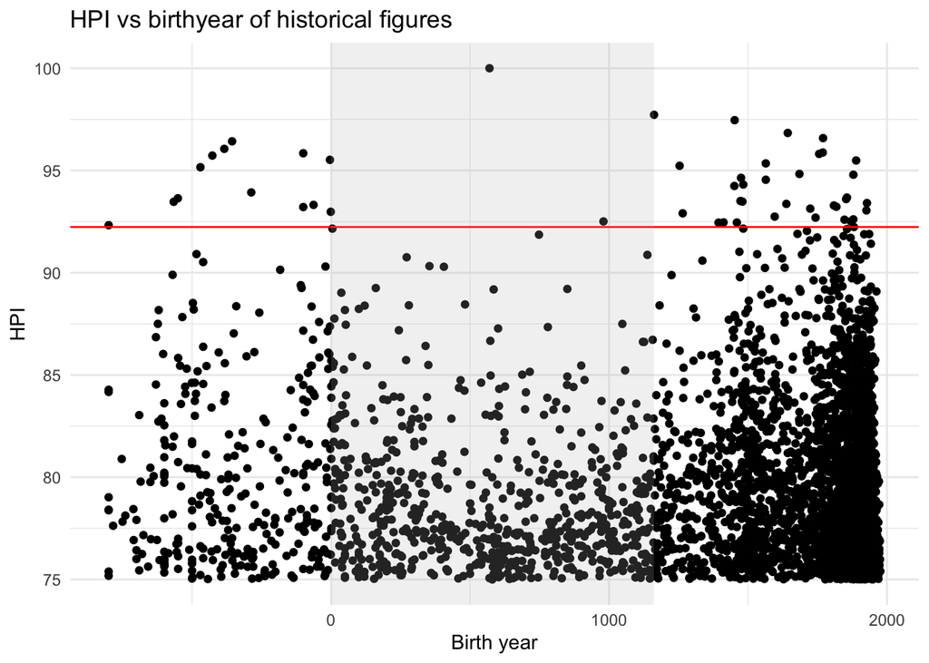

```r
hpi_50 = persons2020_small %>% arrange(desc(hpi)) %>% slice(50:50) %>% pull(hpi)

persons2020_small %>%
  filter(hpi >= 75) %>%
  ggplot() +
  aes(x = birthyear, y = hpi) +
  geom_point() +
  geom_hline(yintercept = hpi_50, col = "red") +
  annotate("rect", fill = "grey", alpha = 0.2,
           xmin = 0, xmax = 1162,
           ymin = -Inf, ymax = Inf) +
  theme_minimal() +
  labs(title = "HPI vs birthyear of historical figures",
       y = "HPI", x = "Birth year")
```

We now split the Pantheon data set and historical eligible population data set into smaller chunks containing data for each separate era. Below are two important quantities:

1. **hpi_generations**: This list contains the name, gender, birth year, and HPI value of individuals within the historical eras.
2. **Epop_generations**: This data set contains the the number of people that populate each era. This population is defined as the difference in the range of population tallies recorded for end points defining an era. The first era runs from 800 BC to right before 700 BC. The population of the era is the cumulative historical population at 700 BC minus the cumulative historical population at 800 BC.

```r
## important quantities mentioned above
hpi_generations = lapply(split(persons2020_small,
                               f = as.factor(persons2020_small$group)),
                         function(xx) xx %>% select(-group))
## number of people in each era
sapply(hpi_generations, nrow)
```

```
##     1     2     3     4     5     6     7     8     9    10    11    12    13
##    74    81   174   194   283   228   260   287   209   239   244   261   234
##    14    15    16    17    18    19    20    21    22    23    24    25    26
##   273   304   263   376   432   548   718   709   680  1007  1378  1432  3136
##    27    28
## 11614 43012
```

```r
Epop_generations = c(dat_HPI_eligible %>%
                       filter(year %in% c(generations, 1980)) %>%
                       pull(cumulative_population) %>% diff())
```

Below we display some information on each of the eras. We display the populations of an era, the cumulative proportion of the historical population through that era, and the number of Pantheon biographies in each era.

```r
cum_prop_population = cumsum(Epop_generations) / sum(Epop_generations)
gen_stats = data.frame(
  gen_start = generations,
  gen_end = c(generations[-1] -1, 1980),
  gen_pop = Epop_generations,
  cum_prop_population = cum_prop_population,
  n = sapply(hpi_generations, nrow)
)
gen_stats
```

```
##    gen_start gen_end   gen_pop cum_prop_population     n
## 1       -800    -701  70529639         0.008407648    74
## 2       -700    -601  74222583         0.017255523    81
## 3       -600    -501  78371715         0.026598004   174
## 4       -500    -401  83034058         0.036496270   194
## 5       -400    -301  88274518         0.047019238   283
## 6       -300    -201  94167019         0.058244634   228
## 7       -200    -101 100797925         0.070260484   260
## 8       -100      -1 108274871         0.083167639   287
## 9          0      99 117544431         0.097179795   209
## 10       100     199 128075368         0.112447314   239
## 11       200     299 140055666         0.129142973   244
## 12       300     399 153712860         0.147466669   261
## 13       400     499 169311754         0.167649867   234
## 14       500     599 187160714         0.189960792   273
## 15       600     699 207619025         0.214710497   304
## 16       700     799 231105457         0.242259956   263
## 17       800     899 258108248         0.273028345   376
## 18       900     999 289180418         0.307500764   432
## 19      1000    1099 324892916         0.346230374   548
## 20      1100    1199 365874983         0.389845345   718
## 21      1200    1299 412835832         0.439058393   709
## 22      1300    1399 466573117         0.494677318   680
## 23      1400    1499 527982026         0.557616634  1007
## 24      1500    1599 598065008         0.628910353  1378
## 25      1600    1699 677942115         0.709726007  1432
## 26      1700    1799 768861931         0.801379967  3136
## 27      1800    1899 872213029         0.905354133 11614
## 28      1900    1980 793960278         1.000000000 43012
```

We now plot the eligible populations of the 28 eras constructed to define temporal peer groups.

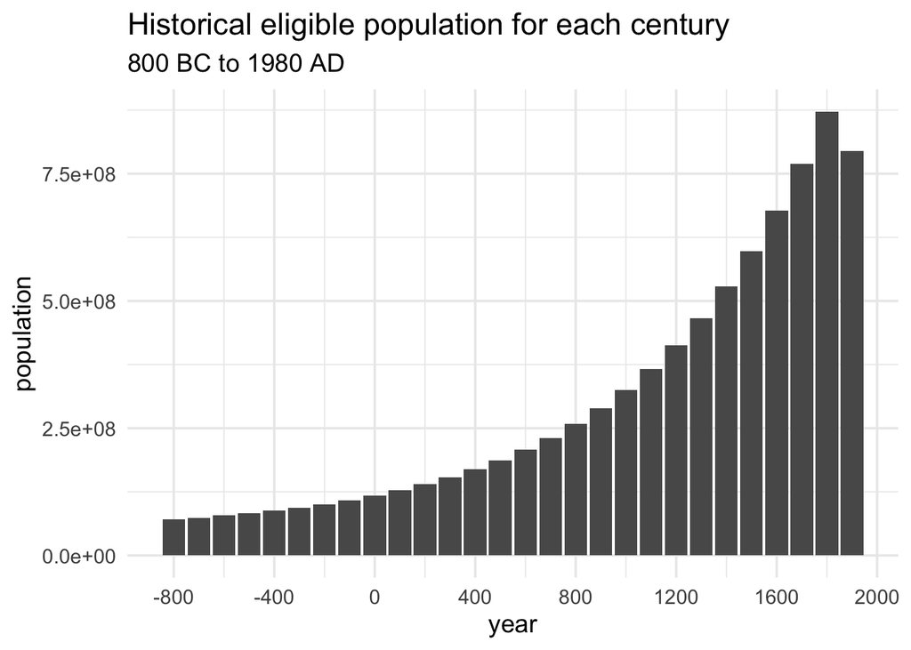

```r
ggplot(gen_stats) +
  aes(x = gen_start, y = gen_pop) +
  geom_bar(stat = "identity") +
  scale_x_continuous(breaks = seq(-800, 2000, by = 400)) +
  theme_minimal(base_size = 14) +
  labs(x = "year", y = "population",
       title ="Historical eligible population for each century",
       subtitle = "800 BC to 1980 AD")
```

Back to topics

## Eras Defined as Separate Chapters in a History Course

Here we define eras as separate chapters in a sensible world history course. There will be 9 eras which follow the periodization for world history section on [UCLA’s Public History Initiative web page](https://phi.history.ucla.edu/nchs/preface/developing-standards/). The first era, The Beginnings of Human Society, dates before the Pantheon data set, so it will contain no bios. We lag birth year by 40 years so that people who populate each era are not children in this era-defining context. These eras are encoded here:

```r
# Era 1: The Beginnings of Human Society
# Era 2: Early Civilizations and the Emergence of Pastoral Peoples, 4000-1000 BCE
# Era 3: Classical Traditions, Major Religions, and Giant Empires, 1000 BCE-300 CE
# Era 4: Expanding Zones of Exchange and Encounter, 300-1000 CE
# Era 5: Intensified Hemispheric Interactions, 1000-1500 CE
# Era 6: Emergence of the First Global Age, 1450-1770
# Era 7: An Age of Revolutions, 1750-1914
# Era 8: A Half-Century of Crisis and Achievement, 1900-1945
# Era 9: The 20th Century Since 1945: Promises and Paradoxes
era_assigner = function(yr, lag = 40){
  yr = yr + lag
  era = 2 + ifelse(yr > -1000,1,0) +
    ifelse(yr > 300,1,0) +
    ifelse(yr > 1000,1,0) +
    ifelse(yr > 1500,1,0) +
    ifelse(yr > 1770,1,0) +
    ifelse(yr > 1900,1,0) +
    ifelse(yr > 1945,1,0)
  era
}

## add era assignments to Pantheon data set
persons2020_small_hist = persons2020 %>%
  dplyr::select(name, occupation, birthyear, gender, bplace_country, hpi) %>%
  filter(birthyear <= 1980) %>%
  mutate(era = era_assigner(birthyear))
```

We now split the Pantheon data set and historical eligible population data set into smaller chunks containing data for each separate era as done above.

```r
generations_hist_by = c(-3500, -1040, 260, 960, 1460, 1730, 1860, 1905, 1940)
generations_hist = c(-3500, -1000, 300, 1000, 1500, 1770, 1900, 1945, 1980)
hpi_generations_hist =
  lapply(split(persons2020_small_hist, f = as.factor(persons2020_small_hist$era)),
         function(xx) xx %>%
           dplyr::select(name, occupation, birthyear, gender, bplace_country, hpi))

Epop_generations_hist = dat_HPI_eligible %>%
  filter(year %in% generations_hist_by) %>%
  pull(cumulative_population) %>% diff()

foo = do.call(rbind, lapply(seq_along(hpi_generations_hist), function(group){
  cbind(hpi_generations_hist[[group]], Epop_generations_hist[[group]], group)
}))
colnames(foo)[5] = "npop"
```

Below we display some information on each of the eras. We display the populations of an era, the cumulative proportion of the historical population through that era, and the number of Pantheon biographies in each era.

```r
cum_prop_population_hist = cumsum(Epop_generations_hist) /
  sum(Epop_generations_hist)
gen_stats_hist = data.frame(
  gen_start = generations_hist[-length(generations_hist)],
  gen_end = c(generations_hist[-c(1,length(generations_hist))]-1, 1980),
  gen_pop = Epop_generations_hist,
  cum_prop_population = cum_prop_population_hist,
  n = sapply(hpi_generations_hist, nrow)
)
gen_stats_hist
```

```
##   gen_start gen_end    gen_pop cum_prop_population     n
## 2     -3500   -1001 1153767313           0.1240372   537
## 3     -1000     299 1183572463           0.2512787  2302
## 4       300     999 1436548575           0.4057167  2047
## 5      1000    1499 2002638231           0.6210129  3326
## 6      1500    1769 1717858513           0.8056935  3903
## 7      1770    1899 1061531169           0.9198148  7144
## 8      1900    1944  398507729           0.9626569  8669
## 9      1945    1980  347357622           1.0000000 41342
```

We now plot the populations of the eight eras defined as separate chapters in a history course.

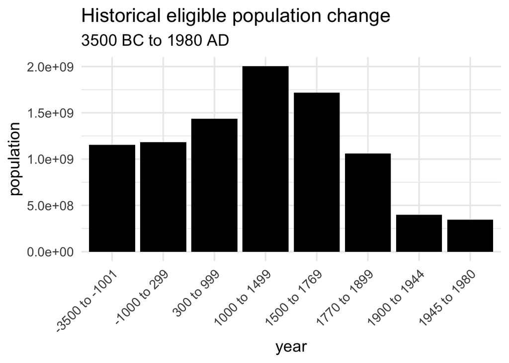

```r
gen_stats_hist = gen_stats_hist %>%
  mutate(cat = paste(gen_start, "to", gen_end), sep = "") %>%
  mutate(cat = fct_relevel(cat, "-3500 to -1001", "-1000 to 299",
                           "300 to 999", "1000 to 1499",
                           "1500 to 1769", "1770 to 1899",
                           "1900 to 1944", "1945 to 1980"))
ggplot(gen_stats_hist) +
  aes(x = cat, y = gen_pop) +
  geom_col(fill = "black") +
  theme_minimal(base_size = 16) +
  scale_x_discrete(guide = guide_axis(angle = 45)) +
  labs( x = "year", y = "population",
        title ="Historical eligible population change",
        subtitle = "3500 BC to 1980 AD")
```

Back to topics

# Full House Modeling

Full House Modeling uses an interpolated empirical CDF $\widetilde{F}_{Y_i}$ as an estimate of the true distribution function for the $Y$ data as in [Yan (2023)](https://arxiv.org/abs/2207.11332). This estimator is constructed in the following manner: First, we construct surrogate sample points $\widetilde{Y}_{i,(1)}, \ldots, \widetilde{Y}_{i,(n_i+1)}$ as,

- $\widetilde{Y}_{i,(1)} =Y_{i,(1)}-Y^{*}_i$,
- $\widetilde{Y}_{i,(j)} =\left(Y_{i,(j)}+Y_{i,(j-1)}\right) / 2, j=2, \ldots, n_i$, and
- $\widetilde{Y}_{i,(n_i+1)} =Y_{i,(n_i)}+Y^{**}_i$.

Here, $Y^*_i$ is the value to construct the lower bound and $Y^{**}_i$ is the value to construct the upper bound. Now let,
$$\begin{equation}
\label{eq:empcdf}
\widetilde{F}_{Y_i}(t) =
\sum_{j=1}^{n_i}\left(\frac{j-1}{n_i} +
\frac{t-\widetilde{Y}_{i,(j)}}{n_i\left(\widetilde{Y}_{i,(j+1)}-\widetilde{Y}_{i,(j)}\right)}\right)
1\left(\widetilde{Y}_{i,(j)} \leq
t<\widetilde{Y}_{i,(j+1)}\right)+1\left(t \geq
\widetilde{Y}_{i,(n_i+1)}\right).
\end{equation}$$
Back to topics

## Eras Defined by Centuries

We first compute $y^{\star\star}$ using the function in the package. First, the number of extreme observations $k$ is calculated following a similar approach to that outlined in Section 2.2.3 of [Yan (2023)](https://arxiv.org/abs/2207.11332) and Section 5 of [Scholz (1995)](https://faculty.washington.edu/fscholz/Reports/extrap.pdf) which is implemented in the function in the package.

```r
system.time({
  kmat = do.call(rbind, mclapply(seq_along(hpi_generations),
    FUN = function(j) {
      k_finder(x = hpi_generations[[j]] %>% pull(hpi))
    }, mc.cores = nCores))
})
```

```
##    user  system elapsed
## 111.485   2.226 176.113
```

```r
kmat
```

```
##       [,1] [,2] [,3]
##  [1,]   32   11   32
##  [2,]   15   11   34
##  [3,]   20   17   58
##  [4,]   60   18   62
##  [5,]   82   21   82
##  [6,]   35   19   70
##  [7,]   75   20   76
##  [8,]   22   22   82
##  [9,]   33   18   66
## [10,]   66   20   72
## [11,]   37   20   74
## [12,]   25   21   78
## [13,]   19   19   72
## [14,]   43   21   80
## [15,]   23   22   86
## [16,]   51   21   78
## [17,]   98   25   98
## [18,]   38   27  108
## [19,]   46   30  128
## [20,]   46   34  152
## [21,]   72   34  150
## [22,]   78   33  146
## [23,]  132   41  190
## [24,]  116   48  232
## [25,]  173   49  238
## [26,]  258   72  390
## [27,]  640  140  876
## [28,]  277  269 1920
```

The task of computing $y^{\star\star}$ is implemented in the function which is included in the package (called below). This function computes $y^{\star\star}$ in the following manner: we first calculate $k$ as above. The upper bound $Y_i^{**}$ is estimated through a connection between $\widetilde{F}_{Y_i}(Y_{i,(n_i)})$ and the regression fit on $(h(p_{i,j,.5,n_i}), Y_{i,(j)})$, $j = n_i -k + 1,\ldots,n_i$ where $h$ is a selected model in the tail probabilities. The tail probability models that we consider are:

- logistic $(h(w) = a + bw + \epsilon)$,
- logistic quadratic $(h(w) = a + bw + cw^2 + \epsilon)$,
- log-logistic $(h(p) = a + b\log(w) + \epsilon)$,
- log-logistic quadratic $(h(p) = a + b\log(w) + c(\log(w))^2 + \epsilon)$,
- logistic cubic $(h(w) = a + bw + cw^2 + dw^3 + \epsilon)$,

where
$$w = \log\left(\frac{p}{1-p}\right).$$

With a model $h$ selected (more on this below), we find $Y_i^{**}$ as the solution of the following optimization problem
$$\begin{equation} \label{eq:optim}
Y_i^{**} = \text{argmin}_y\Big|h^{-1}(Y_{i,(n_i)}) -
\widetilde{F}_{Y_i}(Y_{i,(n_i)};y)\Big|,
\end{equation}$$
where $\widetilde{F}_{Y_i}(\cdot;y)$ is $\widetilde{F}_{Y_i}$ defined in $\eqref{eq:empcdf}$ with $y$ replacing $Y_i^{**}$ in its construction.

We select a tail probability model via the following steps:

1. Fit the logistic and logistic quadratic models. Use BIC to choose among these models.
2. Stop if the optimization problem $\eqref{eq:optim}$ can be solved.
3. If the optimization problem $\eqref{eq:optim}$ cannot be solved, then fit the log-logistic and log-logistic quadratic models. Use BIC to choose among these models.
4. Stop if the optimization problem $\eqref{eq:optim}$ can be solved.
5. If the optimization problem $\eqref{eq:optim}$ cannot be solved, then fit the logistic cubic model.

```r
system.time({
  out = mclapply(seq_along(hpi_generations),
    FUN = function(j) {
      compute_ystarstar(x = hpi_generations[[j]] %>% pull(hpi),
                        k = kmat[j, 1])
      },
    mc.cores = nCores)
})
```

```
##    user  system elapsed
##   0.337   0.225   0.746
```

```r
## get ystarstar values
ystar_mat = do.call(rbind, lapply(seq_along(hpi_generations),
  function(j) out[[j]]$ystar )
)
```

In addition to $y^{\star\star}$, the function includes the tail probability model and data used to fit the model for each era.

The modeling of the $k$ tail probabilities (described above) closely follows Section 2.2.3 of [Yan (2023)](https://arxiv.org/abs/2207.11332). However, there are some notable differences. The main difference is that the simple modeling approach in Section 2.2.3 of [Yan (2023)](https://arxiv.org/abs/2207.11332) does not work well for all eras that we consider. Namely, there is a problem with model fit in some circumstances and a value for $y^{\star\star}$ cannot be computed. Hence the expanded modeling class above.

We now provide the line of best fit for the tail probabilities for each era. We can see adequate fit throughout.

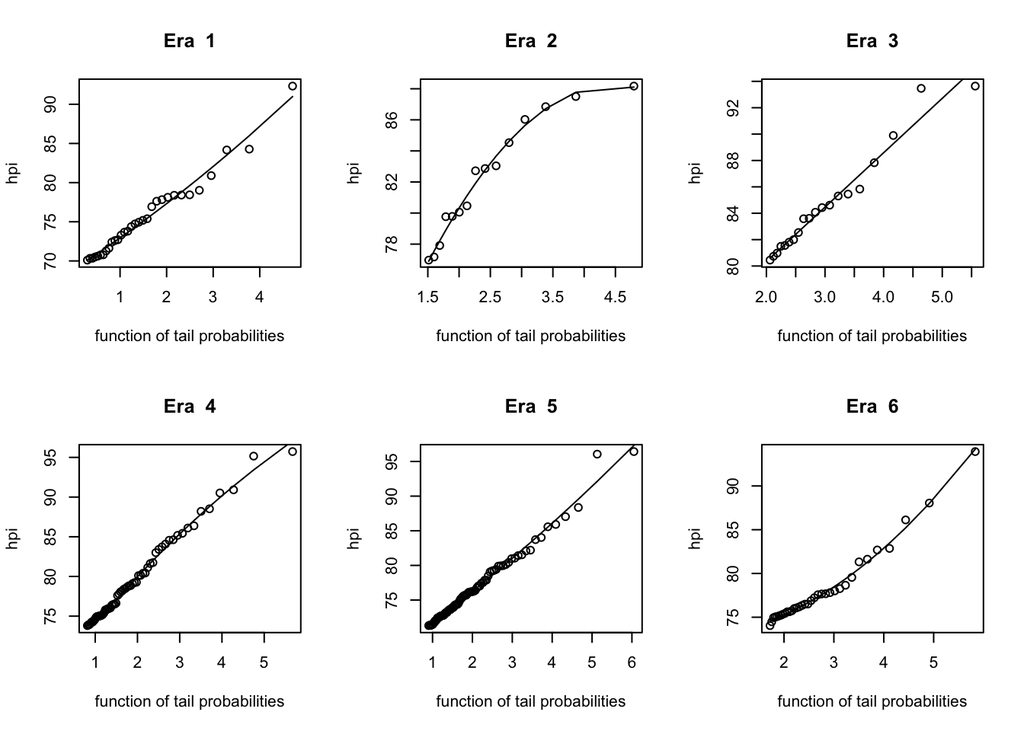

```r
par(mfrow = c(2,3))
for(j in 1:6){
  plot(out[[j]]$W, out[[j]]$Y, main = paste("Era ", j),
       xlab = "function of tail probabilities", ylab = "hpi")
  lines(out[[j]]$W, predict(out[[j]]$model))
}
```

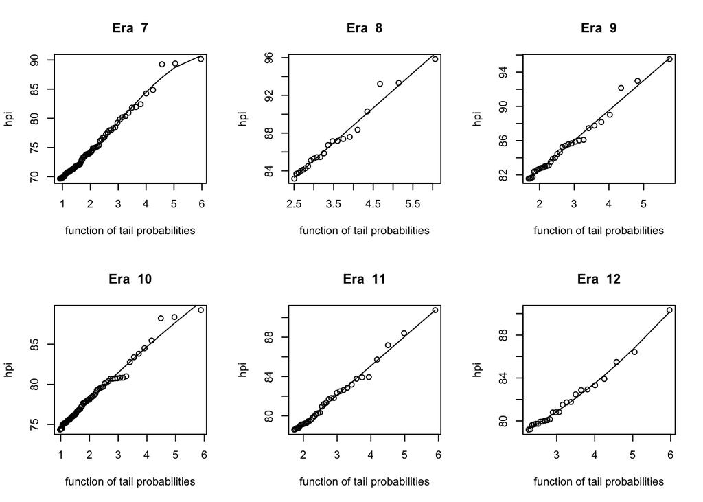

```r
par(mfrow = c(2,3))
for(j in 7:12){
  plot(out[[j]]$W, out[[j]]$Y, main = paste("Era ", j),
       xlab = "function of tail probabilities", ylab = "hpi")
  lines(out[[j]]$W, predict(out[[j]]$model))
}
```

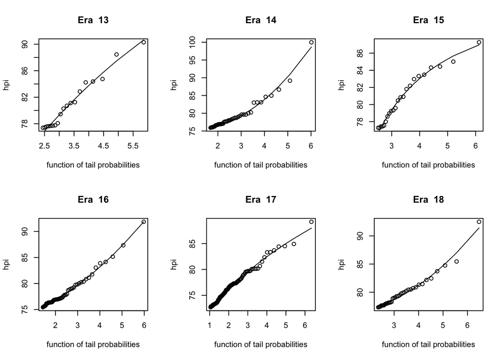

```r
par(mfrow = c(2,3))
for(j in 13:18){
  plot(out[[j]]$W, out[[j]]$Y, main = paste("Era ", j),
       xlab = "function of tail probabilities", ylab = "hpi")
  lines(out[[j]]$W, predict(out[[j]]$model))
}
```

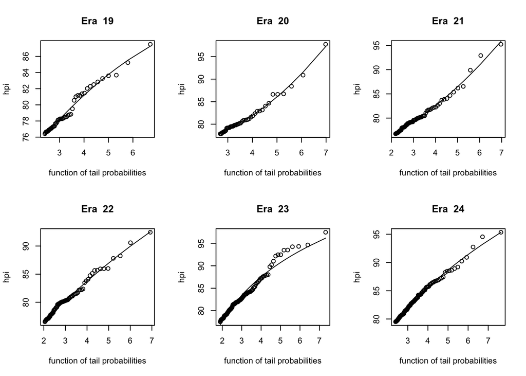

```r
par(mfrow = c(2,3))
for(j in 19:24){
  plot(out[[j]]$W, out[[j]]$Y, main = paste("Era ", j),
       xlab = "function of tail probabilities", ylab = "hpi")
  lines(out[[j]]$W, predict(out[[j]]$model))
}
```

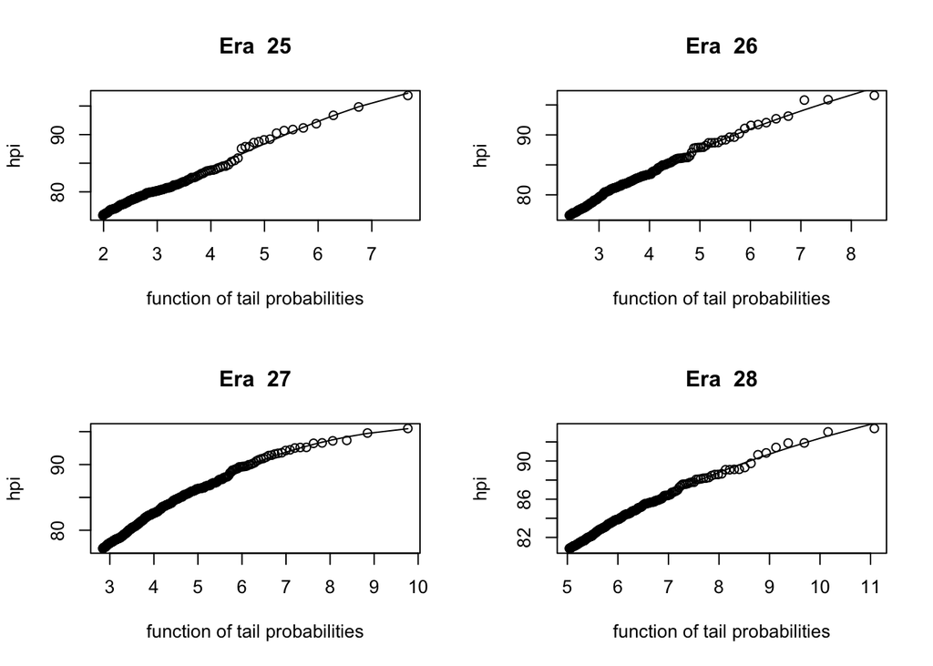

```r
par(mfrow = c(2,2))
for(j in 25:28){
  plot(out[[j]]$W, out[[j]]$Y, main = paste("Era ", j),
       xlab = "function of tail probabilities", ylab = "hpi")
  lines(out[[j]]$W, predict(out[[j]]$model))
}
```

We now compute latent talent estimates using Full House Modeling and the stored $y^{\star\star}$ values. This task is implemented in the function which is included in the package and called below. These estimates of latent talent are
$$F_{X_{i, (N_i - n_i +
j)}}^{-1}\left(F_{U_{i,(j)}}\left(\widetilde{F}_{Y_{i}}\left(Y_{i,(j)}
\right)\right)\right) \approx F_{X_{i, (N_i - n_i +
j)}}^{-1}\left(F_{U_{i,(j)}}\left(U_{i,(j)}\right)\right) = X_{i, (N_i -
n_i + j)},$$
where we suppose that $X_{i,j} \overset{iid}{\sim} \text{Pareto}(\alpha)$, $\alpha = 1.16$ (the value corresponding to the [Pareto principle](https://en.wikipedia.org/wiki/Pareto_principle)), $j = 1,\ldots,n_i$.

```r
## vs your peers
system.time({
  hpi_adjust_vs_peers =
    do.call(rbind,
          mclapply(seq_along(hpi_generations),
                   mc.cores = nCores, function(j){
                     cbind(hpi_generations[[j]],
                           "hpi_talent" =
                       talent_computing_nonpara(ystar = as.numeric(ystar_mat[j, 1]),
                                              y = hpi_generations[[j]] %>% pull(hpi),
                                              npop = Epop_generations[[j]]))
                     })) %>% arrange(desc(hpi_talent))
})
```

```
##     user   system  elapsed
## 1088.729    9.096 1024.893
```

Here is the top 50 list of the most impactful people in history ranked by estimated latent talent obtained via Full House Modeling. In this analysis there are 28 distinct eras defined by centuries to designate peer groups.

```r
kable(hpi_adjust_vs_peers %>% as.data.frame() %>% head(50),
      format = "html") %>%
  kable_styling(full_width = FALSE, position = "left") %>%
  scroll_box(width = "100%")
```

| name | occupation | birthyear | gender | bplace_country | hpi | hpi_talent |
| --- | --- | --- | --- | --- | --- | --- |
| Leonardo da Vinci | INVENTOR | 1452 | M | Italy | 97.46069 | 6.072927 |
| Adolf Hitler | POLITICIAN | 1889 | M | Austria | 95.48942 | 6.053903 |
| Galileo Galilei | ASTRONOMER | 1564 | M | Italy | 95.34711 | 5.980759 |
| Isaac Newton | PHYSICIST | 1643 | M | United Kingdom | 96.83657 | 5.970860 |
| Che Guevara | SOCIAL ACTIVIST | 1928 | M | Argentina | 93.40716 | 5.963232 |
| Ludwig van Beethoven | COMPOSER | 1770 | M | Germany | 96.58397 | 5.963042 |
| Ragnar Lodbrok | NOBLEMAN | 850 | M | United Kingdom | 89.20628 | 5.941581 |
| Johannes Gutenberg | INVENTOR | 1394 | M | Germany | 92.44853 | 5.934824 |
| Elizabeth II | NOBLEMAN | 1926 | F | United Kingdom | 93.04777 | 5.925341 |
| Albert Einstein | PHYSICIST | 1879 | M | Germany | 94.79355 | 5.922415 |
| Genghis Khan | MILITARY PERSONNEL | 1162 | M | Mongolia | 97.72367 | 5.912577 |
| Omar Khayyam | MATHEMATICIAN | 1048 | M | Iran | 87.49654 | 5.903601 |
| Marco Polo | EXPLORER | 1254 | M | Italy | 95.22918 | 5.901202 |
| Avicenna | PHILOSOPHER | 980 | M | Uzbekistan | 92.50853 | 5.894410 |
| William Shakespeare | WRITER | 1564 | M | United Kingdom | 94.54765 | 5.869466 |
| Johann Sebastian Bach | COMPOSER | 1685 | M | Germany | 94.83113 | 5.859015 |
| Ali | RELIGIOUS FIGURE | 601 | M | Saudi Arabia | 87.27485 | 5.852032 |
| Napoleon | POLITICIAN | 1769 | M | France | 95.87986 | 5.848108 |
| Wolfgang Amadeus Mozart | COMPOSER | 1756 | M | Austria | 95.81115 | 5.838490 |
| Charlemagne | POLITICIAN | 748 | M | France | 91.86112 | 5.823556 |
| Muhammad | RELIGIOUS FIGURE | 570 | M | Saudi Arabia | 100.00000 | 5.811752 |
| Timur | MILITARY PERSONNEL | 1336 | M | Uzbekistan | 90.59327 | 5.811743 |
| Sigmund Freud | PSYCHOLOGIST | 1856 | M | Czechia | 93.67498 | 5.797284 |
| Dante Alighieri | WRITER | 1265 | M | Italy | 92.90618 | 5.792068 |
| Michelangelo | PAINTER | 1475 | M | Italy | 94.64203 | 5.786540 |
| Vincent van Gogh | PAINTER | 1853 | M | Netherlands | 93.60249 | 5.783635 |
| Louis XIV of France | POLITICIAN | 1638 | M | France | 93.36695 | 5.782148 |
| Pope Francis | RELIGIOUS FIGURE | 1936 | M | Argentina | 91.89196 | 5.778622 |
| Nelson Mandela | SOCIAL ACTIVIST | 1918 | M | South Africa | 91.88008 | 5.776650 |
| Augustine of Hippo | PHILOSOPHER | 354 | M | Algeria | 90.32378 | 5.762157 |
| René Descartes | PHILOSOPHER | 1596 | M | France | 92.74489 | 5.761320 |
| Attila | POLITICIAN | 406 | M | Hungary | 90.29251 | 5.752414 |
| Saladin | POLITICIAN | 1138 | M | Iraq | 90.87401 | 5.739632 |
| Constantine the Great | POLITICIAN | 272 | M | Serbia | 90.75638 | 5.739569 |
| Al-Ghazali | PHILOSOPHER | 1058 | M | Iran | 85.22429 | 5.733827 |
| Immanuel Kant | PHILOSOPHER | 1724 | M | Russia | 93.13363 | 5.730073 |
| Martin Luther | RELIGIOUS FIGURE | 1483 | M | Germany | 94.31473 | 5.719566 |
| Antonio Vivaldi | COMPOSER | 1678 | M | Italy | 91.90022 | 5.717397 |
| Charles Darwin | BIOLOGIST | 1809 | M | United Kingdom | 93.28950 | 5.713331 |
| Muhammad Ali | BOXER | 1942 | M | United States | 91.41847 | 5.711472 |
| Thomas Jefferson | POLITICIAN | 1743 | M | United States | 92.69298 | 5.707577 |
| Karl Marx | ECONOMIST | 1818 | M | Germany | 93.22597 | 5.704331 |
| Jesus | RELIGIOUS FIGURE | -4 | M | Israel | 95.52158 | 5.704181 |
| Christopher Columbus | EXPLORER | 1451 | M | Italy | 94.24199 | 5.703950 |
| Thomas Aquinas | PHILOSOPHER | 1225 | M | Italy | 89.88498 | 5.699882 |
| Petrarch | WRITER | 1304 | M | Italy | 88.24960 | 5.696999 |
| Elizabeth I of England | POLITICIAN | 1533 | F | United Kingdom | 90.90742 | 5.692972 |
| Ivar the Boneless | POLITICIAN | 900 | M | Denmark | 85.46084 | 5.683247 |
| Giovanni Boccaccio | WRITER | 1313 | M | Italy | 87.81245 | 5.677156 |
| Rembrandt | PAINTER | 1606 | M | Netherlands | 91.16378 | 5.674015 |

```r
#write_csv(hpi_adjust_vs_peers, "hpi_adjust_vs_peers.csv")
```

We now display some information on the components of Full House modeling. From [Yan (2023)](https://arxiv.org/abs/2207.11332) we have that
$$\widetilde{F}_{Y_i}\left(Y_{i,(j)}\right) \approx U_{i,(j)},$$
where $\approx$ means approximately distributed, and $U_{i,(j)} \sim \operatorname{Beta}(j, n_i+1-j)$. Notice that $\widetilde{F}_{Y_i}$ satisfies the following,
$$\begin{align*}
\widetilde{F}_{Y_i}\left(Y_{i,(n_i)}\right)
&= \frac{n_i - 1}{n_i} + \frac{Y_{i,(n_i)} -
\widetilde{Y}_{i,(n_i)}}{n_i\left(Y_{i,(n_i)} + Y_i^{\star\star} -
\widetilde{Y}_{i,(n_i)}\right)} \\
&= 1 - \frac{1}{n_i} +
\frac{1}{n_i}\left(\frac{\frac{Y_{i,(n_i)} -
Y_{i,(n_i-1)}}{2}}{\frac{Y_{i,(n_i)} - Y_{i,(n_i-1)}}{2} +
Y_{i}^{\star\star}}\right).
\end{align*}$$
Thus, how far someone stands above their peers is a balance between how far above their closest peer and the estimated maximum allowable value $Y_i^{\star\star}$ which is obtained from modeling of the tail probabilities of all the extreme performers. In this manner, increased spacing between successive extreme performers may offset the effect that $Y_{i, (n_i)} - Y_{i(n_i-1)}$ has $\widetilde{F}_{Y_i}\left(Y_{i,(n_i)}\right)$ through an increase in $Y_i^{\star\star}$.

In the table below, we report:

1. The difference that the highest achiever stood out from the next highest, $Y_{i, (n_i)} - Y_{i(n_i-1)}$.
2. The number of memorable people in the era, $n_i$.
3. The upper bound $Y_i^{\star\star}$.
4. The realized Beta value $U_{i,(j)} \sim \operatorname{Beta}(j, n_i+1-j)$.
5. The percentile $F_{U_{i,(j)}}\left(U_{i,(j)}\right)$. This is a measure of how far the highest achiever stood from their peers.

```r
foo = data.frame(diff = sapply(hpi_generations, function(x){
  -head(x %>% pull(hpi) %>% diff(), 1)}),
  n = sapply(hpi_generations, nrow),
  yss = ystar_mat) %>%
  mutate(balance = (diff/2)/((diff/2) + yss),
         U_beta = 1 - 1/n + 1/n * (diff/2)/((diff/2) + yss),
         p_beta = pbeta(U_beta, n, 1),
         group = seq_along(hpi_generations))
foo
```

```
##          diff     n        yss    balance    U_beta    p_beta group
## 1   8.0489270    74  4.4261825 0.47623146 0.9929220 0.5911822     1
## 2   0.6719221    81  0.8873870 0.27462425 0.9910447 0.4825633     2
## 3   0.1723156   174  1.1624756 0.06900168 0.9946494 0.3931760     3
## 4   0.5703340   194  4.7400672 0.05674701 0.9951379 0.3884645     4
## 5   0.3699410   283  0.6420733 0.22365260 0.9972567 0.4595929     5
## 6   5.8789683   228  6.5769711 0.30888436 0.9969688 0.5004912     6
## 7   0.7516898   260 10.0000000 0.03622307 0.9962932 0.3807670     7
## 8   2.5249697   287  4.5907812 0.21568896 0.9972672 0.4559443     8
## 9   2.5409384   209  2.7748592 0.31405836 0.9967180 0.5030480     9
## 10  0.8609844   239  9.2392411 0.04451955 0.9960022 0.3838914    10
## 11  2.3492381   244  2.3190261 0.33621591 0.9972796 0.5144337    11
## 12  3.9030049   261  3.4316727 0.36251885 0.9975575 0.5282102    12
## 13  1.8418911   234  2.6709092 0.25639833 0.9968222 0.4748361    13
## 14 10.8172482   273  7.4056971 0.42207652 0.9978831 0.5607186    14
## 15  2.2600348   304  1.1467914 0.49631633 0.9983431 0.6040481    15
## 16  4.5177623   263  4.4808523 0.33515882 0.9974721 0.5139224    16
## 17  4.2827638   376  1.2262339 0.63587476 0.9990316 0.6946816    17
## 18  7.0476906   432  4.1928789 0.45665041 0.9987422 0.5806010    18
## 19  2.2722558   548  1.5525492 0.42256019 0.9989463 0.5611628    19
## 20  6.8496548   718  5.4907817 0.38413835 0.9991423 0.5400325    20
## 21  2.3229971   709  3.3843591 0.25550702 0.9989499 0.4747893    21
## 22  1.8552597   680  2.0255888 0.31410808 0.9989913 0.5034665    22
## 23  2.8186572  1007  0.6989234 0.66848205 0.9996708 0.7177941    23
## 24  0.7994663  1378  0.7899241 0.33600701 0.9995181 0.5147093    24
## 25  2.0054387  1432  4.0050485 0.20023279 0.9994415 0.4493332    25
## 26  0.7041090  3136  6.9287789 0.04835360 0.9996965 0.3860491    26
## 27  0.6958694 11614  0.5594257 0.38345808 0.9999469 0.5397991    27
## 28  0.3593854 43012  9.6435987 0.01829251 0.9999772 0.3746666    28
```

Below are the highest achievers in each era as judged by the percentile $F_{U_{i,(j)}}\left(U_{i,(j)}\right)$.

```r
bar = cbind(foo, do.call(rbind,
  lapply(seq_along(hpi_generations),
         function(j) hpi_generations[[j]][1, ]))) %>%
  select(name, birthyear, hpi, diff, yss, balance, p_beta) %>%
  mutate(across(hpi:p_beta, ~round(.x, 3))) %>%
  arrange(desc(p_beta))
bar
```

```
##                     name birthyear     hpi   diff    yss balance p_beta
## 23     Leonardo da Vinci      1452  97.461  2.819  0.699   0.668  0.718
## 17        Ragnar Lodbrok       850  89.206  4.283  1.226   0.636  0.695
## 15                   Ali       601  87.275  2.260  1.147   0.496  0.604
## 1                  Homer      -800  92.325  8.049  4.426   0.476  0.591
## 18              Avicenna       980  92.509  7.048  4.193   0.457  0.581
## 14              Muhammad       570 100.000 10.817  7.406   0.422  0.561
## 19          Omar Khayyam      1048  87.497  2.272  1.553   0.423  0.561
## 20          Genghis Khan      1162  97.724  6.850  5.491   0.384  0.540
## 27          Adolf Hitler      1889  95.489  0.696  0.559   0.383  0.540
## 12    Augustine of Hippo       354  90.324  3.903  3.432   0.363  0.528
## 24       Galileo Galilei      1564  95.347  0.799  0.790   0.336  0.515
## 11 Constantine the Great       272  90.756  2.349  2.319   0.336  0.514
## 16           Charlemagne       748  91.861  4.518  4.481   0.335  0.514
## 9                  Jesus        -4  95.522  2.541  2.775   0.314  0.503
## 22    Johannes Gutenberg      1394  92.449  1.855  2.026   0.314  0.503
## 6             Archimedes      -287  93.927  5.879  6.577   0.309  0.500
## 2                  Aesop      -620  88.173  0.672  0.887   0.275  0.483
## 13                Attila       406  90.293  1.842  2.671   0.256  0.475
## 21            Marco Polo      1254  95.229  2.323  3.384   0.256  0.475
## 5    Alexander the Great      -356  96.428  0.370  0.642   0.224  0.460
## 8          Julius Caesar      -100  95.844  2.525  4.591   0.216  0.456
## 25          Isaac Newton      1643  96.837  2.005  4.005   0.200  0.449
## 3              Confucius      -551  93.641  0.172  1.162   0.069  0.393
## 4                  Plato      -427  95.730  0.570  4.740   0.057  0.388
## 26  Ludwig van Beethoven      1770  96.584  0.704  6.929   0.048  0.386
## 10              Commodus       161  89.252  0.861  9.239   0.045  0.384
## 7               Hannibal      -183  90.143  0.752 10.000   0.036  0.381
## 28           Che Guevara      1928  93.407  0.359  9.644   0.018  0.375
```

```r
#write_csv(bar,file = "high_achievers_century.csv")
```

At each era we now calculate the $P(X \leq x \mid p)$ and $P(X \geq x \mid p)$ where:

1. $X$ is the number of top 50 bios at or before the specified era, and $x$ is the observed value. $X \sim \text{Binomial(50, p)}$.
2. The proportion $p$ is the proportion of the cumulative historical population at or the specified era.

We calculate both probabilities and corresponding chances $1 / P(X \leq x \mid p)$ and $1 / P(X \geq x \mid p)$ for both the era-adjusted list obtained using Full House Modeling with centuries to define distinct eras and the top 50 raw unadjusted Pantheon ranking list. The plot indicates that the Pantheon ranking list exhibits favoritism for historical figures at or prior to 600 AD with massive favoritism for historical figures at or prior to 0 AD. The era-adjusted rankings obtained via Full House Modeling do not exhibit preferential biases to historical figures from any era.

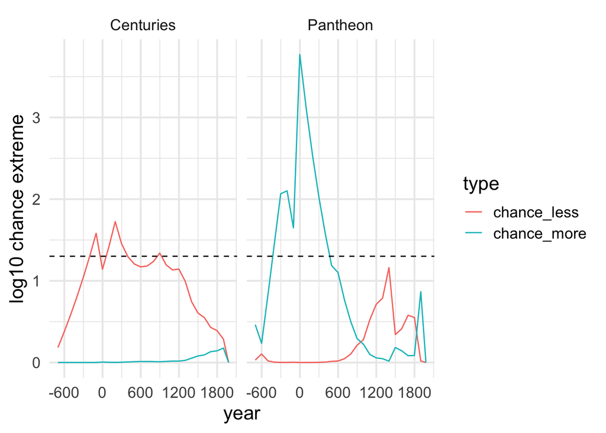

Back to topics

## Eras Defined as Separate Chapters in a History Course

We now in consider Full House Modeling when a history course is used to define distinct eras. First, the number of extreme observations $k$ is calculated. In this analysis, we will let $k = \lfloor1.3\sqrt n \rfloor$, the lower bound of the range for $k$ in [Scholz (1995)](https://faculty.washington.edu/fscholz/Reports/extrap.pdf). This value of $k$ was chosen so that our tail probability modeling fits the data well (see the eight plots below).

```r
system.time({
  kmat_hist = do.call(rbind, mclapply(seq_along(hpi_generations_hist),
    FUN = function(j) {
      k_finder(x = hpi_generations_hist[[j]] %>% pull(hpi))
    }, mc.cores = nCores))
})
```

```
##    user  system elapsed
## 205.188   3.404 171.654
```

```r
kmat_hist[, -1] = t(apply(kmat_hist, 1, function(x) c(min(x[-1]), max(x[-1]))))
kmat_hist
```

```
##      [,1] [,2] [,3]
## [1,]   30   30  126
## [2,]  322   62  322
## [3,]  221   58  298
## [4,]  178   74  406
## [5,]  391   81  448
## [6,]  545  109  650
## [7,]  620  121  732
## [8,]  344  264 1876
```

We now calculate $y^{\star\star}$ and modeling information quantities through a call to the function.

```r
system.time({
  out = mclapply(seq_along(hpi_generations_hist),
    FUN = function(j) {
      compute_ystarstar(x = hpi_generations_hist[[j]] %>% pull(hpi),
                        #k = kmat_hist[j, 1])
                        k = kmat_hist[j, 2])
      },
    mc.cores = nCores)
})
```

```
##    user  system elapsed
##   0.243   0.180   0.385
```

```r
## get ystarstar values
ystar_mat_hist = do.call(rbind, lapply(seq_along(hpi_generations_hist),
  function(j) out[[j]]$ystar )
)
ystar_mat_hist
```

```
##            [,1]
## [1,] 1.35430617
## [2,] 0.03202988
## [3,] 3.74173336
## [4,] 0.50991230
## [5,] 4.05855169
## [6,] 2.07749073
## [7,] 4.34989441
## [8,] 0.94140127
```

We now provide the line of best fit for the tail probabilities for each era. We can see adequate fit throughout.

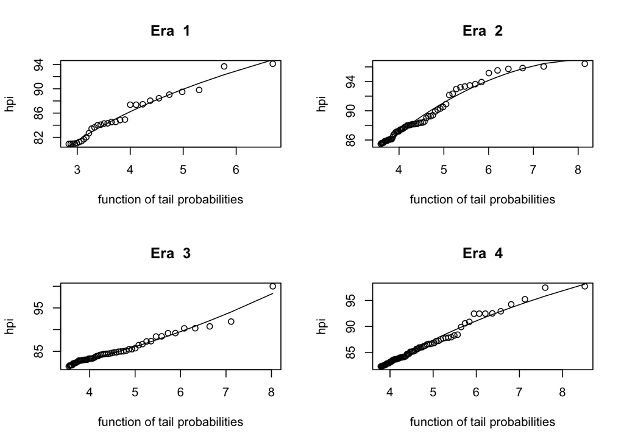

```r
par(mfrow = c(2,2))
for(j in 1:4){
  plot(out[[j]]$W, out[[j]]$Y, main = paste("Era ", j),
       xlab = "function of tail probabilities", ylab = "hpi")
  lines(out[[j]]$W, predict(out[[j]]$model))
}
```

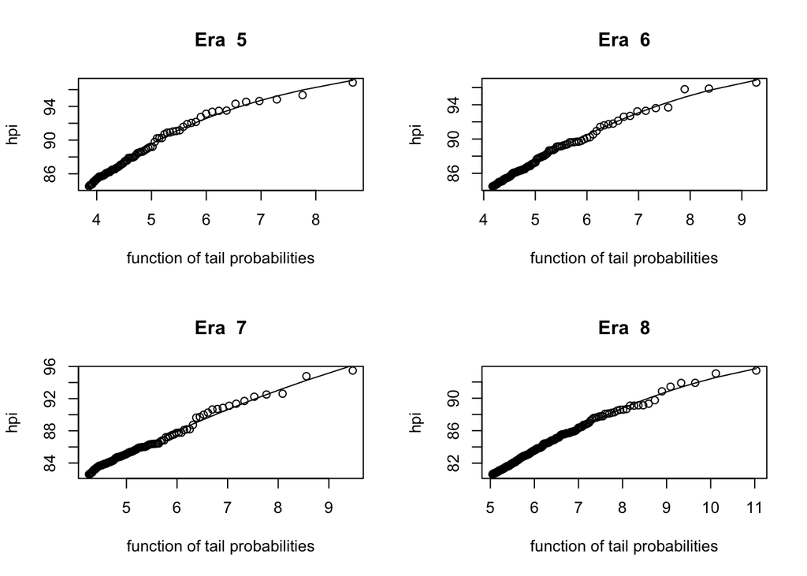

```r
par(mfrow = c(2,2))
for(j in 5:8){
  plot(out[[j]]$W, out[[j]]$Y, main = paste("Era ", j),
       xlab = "function of tail probabilities", ylab = "hpi")
  lines(out[[j]]$W, predict(out[[j]]$model))
}
```

We now compute latent talent estimates using Full House Modeling and the stored $y^{\star\star}$ values via the function.

```r
system.time({
  hpi_adjust_hist =
    do.call(rbind,
      mclapply(seq_along(hpi_generations_hist),
        mc.cores = nCores, function(j){
          cbind(hpi_generations_hist[[j]],
                           "hpi_talent" =
                  talent_computing_nonpara(ystar = as.numeric(ystar_mat_hist[j, 1]),
                                   y = hpi_generations_hist[[j]] %>% pull(hpi),
                                   npop = Epop_generations_hist[[j]]))
          }))
})
```

```
##    user  system elapsed
## 993.277   6.136 923.023
```

Here is the top 50 list of the most impactful people in history ranked by estimated latent talent obtained via Full House Modeling. In this analysis there are 8 distinct eras defined using a history course as a guide.

```r
hpi_adjust_hist = hpi_adjust_hist %>% arrange(desc(hpi_talent))
kable(hpi_adjust_hist %>% as.data.frame() %>% head(50), format = "html") %>%
  kable_styling(full_width = FALSE, position = "left") %>%
  scroll_box(width = "100%")
```

| name | occupation | birthyear | gender | bplace_country | hpi | hpi_talent |
| --- | --- | --- | --- | --- | --- | --- |
| Alexander the Great | MILITARY PERSONNEL | -356 | M | Greece | 96.42753 | 6.327337 |
| Muhammad | RELIGIOUS FIGURE | 570 | M | Saudi Arabia | 100.00000 | 6.173727 |
| Genghis Khan | MILITARY PERSONNEL | 1162 | M | Mongolia | 97.72367 | 6.146114 |
| Isaac Newton | PHYSICIST | 1643 | M | United Kingdom | 96.83657 | 6.112011 |
| Leonardo da Vinci | INVENTOR | 1452 | M | Italy | 97.46069 | 6.093601 |
| Moses | RELIGIOUS FIGURE | -1393 | M | Egypt | 94.11067 | 6.044840 |
| Ludwig van Beethoven | COMPOSER | 1770 | M | Germany | 96.58397 | 6.032827 |
| Abraham | RELIGIOUS FIGURE | -1813 | M | Iraq | 93.67735 | 6.005459 |
| Galileo Galilei | ASTRONOMER | 1564 | M | Italy | 95.34711 | 5.995458 |
| Charlemagne | POLITICIAN | 748 | M | France | 91.86112 | 5.953878 |
| Marco Polo | EXPLORER | 1254 | M | Italy | 95.22918 | 5.949476 |
| Aristotle | PHILOSOPHER | -384 | M | Greece | 96.05759 | 5.945181 |
| Johann Sebastian Bach | COMPOSER | 1685 | M | Germany | 94.83113 | 5.921985 |
| Christopher Columbus | EXPLORER | 1451 | M | Italy | 94.24199 | 5.910020 |
| Napoleon | POLITICIAN | 1769 | M | France | 95.87986 | 5.901557 |
| Constantine the Great | POLITICIAN | 272 | M | Serbia | 90.75638 | 5.893300 |
| Wolfgang Amadeus Mozart | COMPOSER | 1756 | M | Austria | 95.81115 | 5.891509 |
| Michelangelo | PAINTER | 1475 | M | Italy | 94.64203 | 5.873392 |
| Julius Caesar | POLITICIAN | -100 | M | Italy | 95.84403 | 5.865351 |
| Adolf Hitler | POLITICIAN | 1889 | M | Austria | 95.48942 | 5.859334 |
| Dante Alighieri | WRITER | 1265 | M | Italy | 92.90618 | 5.855182 |
| Che Guevara | SOCIAL ACTIVIST | 1928 | M | Argentina | 93.40716 | 5.852756 |
| William Shakespeare | WRITER | 1564 | M | United Kingdom | 94.54765 | 5.847409 |
| Zoroaster | RELIGIOUS FIGURE | -2000 | M | Iran | 89.80095 | 5.844646 |
| Augustine of Hippo | PHILOSOPHER | 354 | M | Algeria | 90.32378 | 5.832012 |
| Attila | POLITICIAN | 406 | M | Hungary | 90.29251 | 5.828049 |
| Plato | PHILOSOPHER | -427 | M | Greece | 95.73000 | 5.826287 |
| Avicenna | PHILOSOPHER | 980 | M | Uzbekistan | 92.50853 | 5.819918 |
| Tutankhamun | POLITICIAN | -1341 | M | Egypt | 89.49116 | 5.819444 |
| Martin Luther | RELIGIOUS FIGURE | 1483 | M | Germany | 94.31473 | 5.814479 |
| Albert Einstein | PHYSICIST | 1879 | M | Germany | 94.79355 | 5.810397 |
| Joan of Arc | MILITARY PERSONNEL | 1412 | F | France | 92.46169 | 5.794254 |
| Elizabeth II | NOBLEMAN | 1926 | F | United Kingdom | 93.04777 | 5.787988 |
| Jesus | RELIGIOUS FIGURE | -4 | M | Israel | 95.52158 | 5.782102 |
| Sigmund Freud | PSYCHOLOGIST | 1856 | M | Czechia | 93.67498 | 5.779890 |
| Vasco da Gama | EXPLORER | 1460 | M | Portugal | 92.45473 | 5.778893 |
| Jacob | RELIGIOUS FIGURE | -1653 | M | NA | 89.03575 | 5.775140 |
| Vincent van Gogh | PAINTER | 1853 | M | Netherlands | 93.60249 | 5.770777 |
| Johannes Gutenberg | INVENTOR | 1394 | M | Germany | 92.44853 | 5.768598 |
| Nicolaus Copernicus | ASTRONOMER | 1473 | M | Poland | 93.50835 | 5.766144 |
| Ragnar Lodbrok | NOBLEMAN | 850 | M | United Kingdom | 89.20628 | 5.761726 |
| Ferdinand Magellan | EXPLORER | 1480 | M | Portugal | 93.47959 | 5.760497 |
| Umar | POLITICIAN | 585 | M | Saudi Arabia | 89.18275 | 5.760294 |
| Socrates | PHILOSOPHER | -470 | M | Greece | 95.15967 | 5.751739 |
| Louis XIV of France | POLITICIAN | 1638 | M | France | 93.36695 | 5.736008 |
| Nefertiti | COMPANION | -1400 | F | Egypt | 88.44136 | 5.735798 |
| Saladin | POLITICIAN | 1138 | M | Iraq | 90.87401 | 5.733516 |
| Timur | MILITARY PERSONNEL | 1336 | M | Uzbekistan | 90.59327 | 5.726196 |
| Immanuel Kant | PHILOSOPHER | 1724 | M | Russia | 93.13363 | 5.715855 |
| Charles Darwin | BIOLOGIST | 1809 | M | United Kingdom | 93.28950 | 5.714740 |

```r
#write_csv(hpi_adjust_hist, "hpi_adjust_hist.csv")
```

We now display some information on the components of Full House modeling. In the table below, we report:

1. The difference that the highest achiever stood out from the next highest, $Y_{i, (n_i)} - Y_{i(n_i-1)}$.
2. The number of memorable people in the era, $n_i$.
3. The upper bound $Y_i^{\star\star}$.
4. The realized Beta value $U_{i,(j)} \sim \operatorname{Beta}(j, n_i+1-j)$.
5. The percentile $F_{U_{i,(j)}}\left(U_{i,(j)}\right)$. This is a measure of how far the highest achiever stood from their peers.

```r
foo_hist = data.frame(diff = sapply(hpi_generations_hist, function(x){
  -head(x %>% pull(hpi) %>% diff(), 1)}),
  n = sapply(hpi_generations_hist, nrow),
  yss = ystar_mat_hist) %>%
  mutate(balance = (diff/2)/((diff/2) + yss),
         U_beta = 1 - 1/n + 1/n * (diff/2)/((diff/2) + yss),
         p_beta = pbeta(U_beta, n, 1),
         group = seq_along(hpi_generations_hist))
foo_hist
```

```
##        diff     n        yss    balance    U_beta    p_beta group
## 2 0.4333169   537 1.35430617 0.13791426 0.9983946 0.4219880     1
## 3 0.3699410  2302 0.03202988 0.85239711 0.9999359 0.8627696     2
## 4 8.1388762  2047 3.74173336 0.52097667 0.9997660 0.6193533     3
## 5 0.2629782  3326 0.50991230 0.20500282 0.9997610 0.4515396     4
## 6 1.4894533  3903 4.05855169 0.15504549 0.9997835 0.4295376     5
## 7 0.7041090  7144 2.07749073 0.14490551 0.9998803 0.4252212     6
## 8 0.6958694  8669 4.34989441 0.07406287 0.9998932 0.3961404     7
## 9 0.3593854 41342 0.94140127 0.16028335 0.9999797 0.4318292     8
```

Below are the highest achievers in each era as judged by the percentile $F_{U_{i,(j)}}\left(U_{i,(j)}\right)$.

```r
bar_hist = cbind(foo_hist, do.call(rbind,
  lapply(seq_along(hpi_generations_hist),
         function(j) hpi_generations_hist[[j]][1, ]))) %>%
  select(name, birthyear, hpi, diff, yss, balance, p_beta) %>%
  mutate(across(hpi:p_beta, ~round(.x, 3))) %>%
  arrange(desc(p_beta))
bar_hist
```

```
##                   name birthyear     hpi  diff   yss balance p_beta
## 3  Alexander the Great      -356  96.428 0.370 0.032   0.852  0.863
## 4             Muhammad       570 100.000 8.139 3.742   0.521  0.619
## 5         Genghis Khan      1162  97.724 0.263 0.510   0.205  0.452
## 9          Che Guevara      1928  93.407 0.359 0.941   0.160  0.432
## 6         Isaac Newton      1643  96.837 1.489 4.059   0.155  0.430
## 7 Ludwig van Beethoven      1770  96.584 0.704 2.077   0.145  0.425
## 2                Moses     -1393  94.111 0.433 1.354   0.138  0.422
## 8         Adolf Hitler      1889  95.489 0.696 4.350   0.074  0.396
```

At each era we now calculate the $P(X \leq x \mid p)$ and $P(X \geq x \mid p)$ where:

1. $X$ is the number of top 50 bios at or before the specified era, and $x$ is the observed value. $X \sim \text{Binomial(50, p)}$.
2. The proportion $p$ is the proportion of the cumulative historical population at or the specified era.

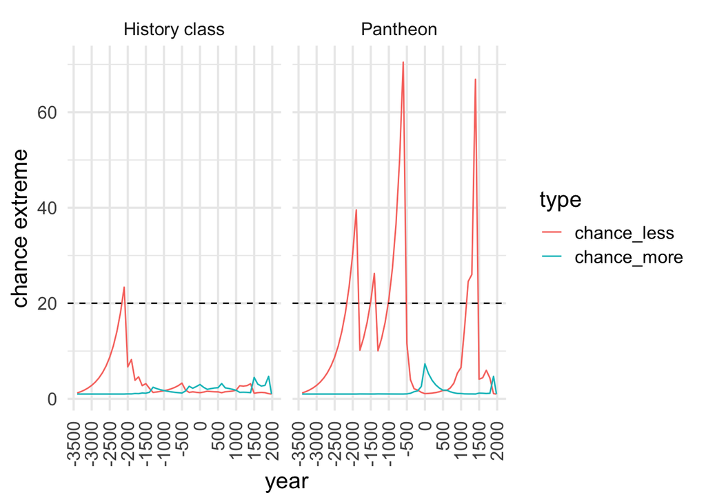

It is worth noting that the above analysis includes the full range of years in the Pantheon data set, but the earliest birthdate in either top 50 list is 2000 BC. We recalculate both probabilities and corresponding chances $1 / P(X \leq x \mid p)$ and $1 / P(X \geq x \mid p)$ for both the era-adjusted list obtained using Full House Modeling with units in a history class to define distinct eras and the top 50 raw unadjusted Pantheon ranking list restricted to 2000 BC - 1980 AD. The plot indicates that both methods exhibit favoritism to older era historical figures.

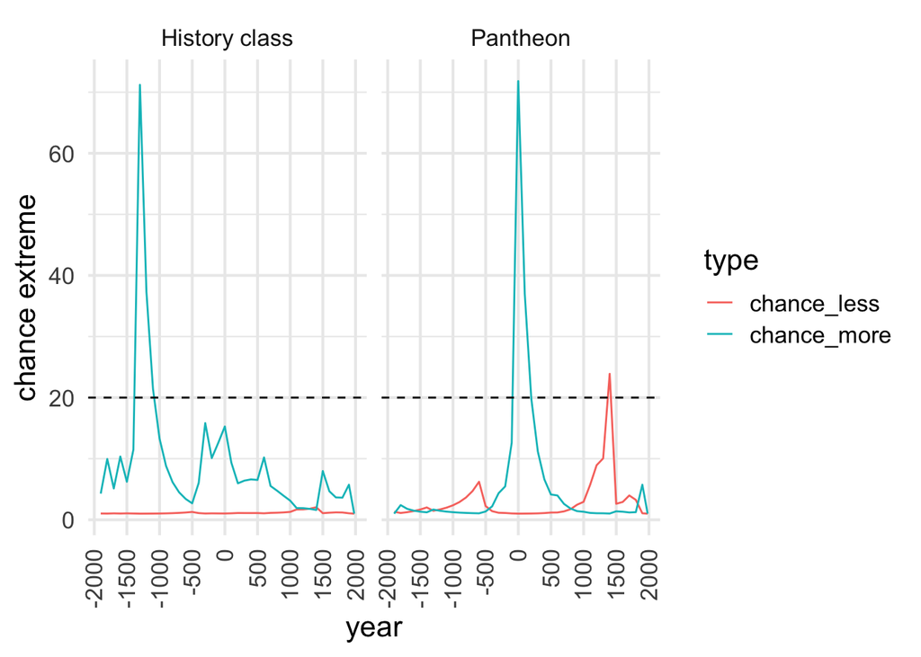

Back to topics

# Comparison of Approaches

We now investigate how our era-adjusted rankings of historical figures compare with the original Pantheon ranking list. The plots below show agreement proportion as a function of the number of top biographies. For ranking lists displaying the top 100 or fewer biographies, our approach which defined eras by centuries exhibits much less agreement with the Pantheon ranking list than the approach which defined eras as separate units in a history course. The opposite is observed after the number of top biographies exceeds 100. Recall that our two era-adjustment methods were applied to data sets with different date ranges, and are therefore compared to different Pantheon ranking lists.

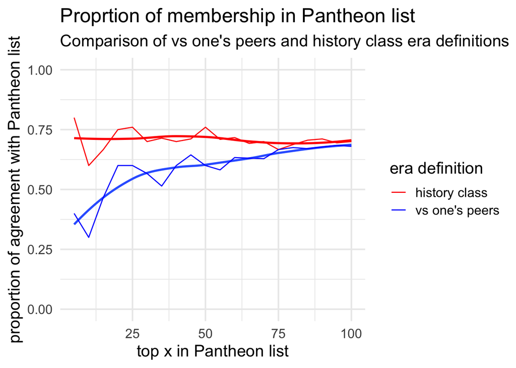

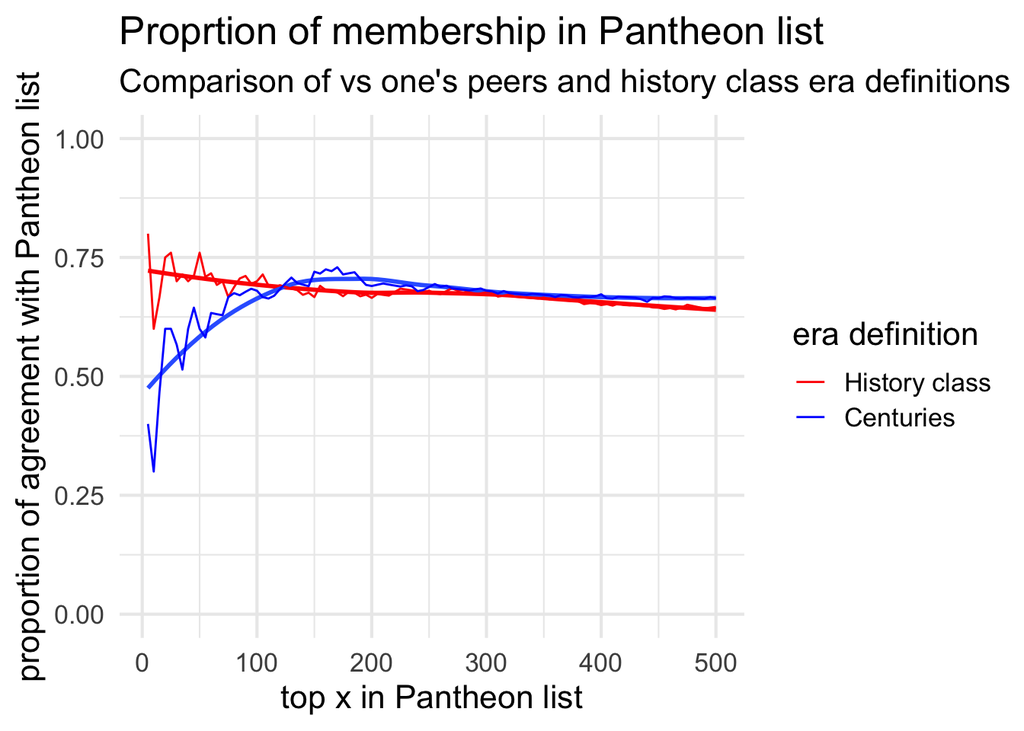

Back to topics

# Interesting Changes in Rankings

We have already discussed how each era-adjusted rankings of historical figures agree with the original Pantheon ranking list, and the differences in historical figures included in each top 50 list. Here we take a closer look at how ranking lists change when era-adjustment is applied. Back to topics

## Eras Defined as Centuries

```r
foo_vs_peers = cbind(
paste(hpi_adjust_vs_peers$name,
      hpi_adjust_vs_peers$occupation,
      hpi_adjust_vs_peers$birthyear, sep = " "),
paste(persons2020_small$name,
      persons2020_small$occupation,
      persons2020_small$birthyear, sep = " "))

combined_vs_peers = data.frame(name = hpi_adjust_vs_peers$name,
                      occupation = hpi_adjust_vs_peers$occupation,
                      birthyear = hpi_adjust_vs_peers$birthyear,
                      rank_vs_peers = 1:nrow(hpi_adjust_vs_peers),
                      rank_Pantheon = sapply(foo_vs_peers[, 1], function(x) {
                        which(foo_vs_peers[, 2] == x)
                        }))
rownames(combined_vs_peers) = c()
```

The tables in this section display historical figures that are elevated or penalized by era-adjustment when eras are defined by centuries. Each code block below will output two tables. The first table will be the 10 historical figures most elevated from the top-x ranking list after era adjustment is applied. The second table will be the 10 historical figures from the top-x Pantheon list most penalized by era-adjustment.

```r
# top 50
## elevated by era-adjustment
foo = combined_vs_peers[1:50, ] %>%
  mutate(diff = rank_Pantheon - rank_vs_peers) %>%
  arrange(desc(diff)) %>%
  head(10)
kable(foo, format = "html") %>%
  kable_styling(full_width = FALSE, position = "left") %>%
  scroll_box(width = "100%")
```

| name | occupation | birthyear | rank_vs_peers | rank_Pantheon | diff |
| --- | --- | --- | --- | --- | --- |
| Al-Ghazali | PHILOSOPHER | 1058 | 35 | 391 | 356 |
| Ivar the Boneless | POLITICIAN | 900 | 48 | 365 | 317 |
| Ali | RELIGIOUS FIGURE | 601 | 17 | 211 | 194 |
| Omar Khayyam | MATHEMATICIAN | 1048 | 12 | 203 | 191 |
| Giovanni Boccaccio | WRITER | 1313 | 49 | 183 | 134 |
| Ragnar Lodbrok | NOBLEMAN | 850 | 7 | 116 | 109 |
| Petrarch | WRITER | 1304 | 46 | 155 | 109 |
| Timur | MILITARY PERSONNEL | 1336 | 22 | 82 | 60 |
| Augustine of Hippo | PHILOSOPHER | 354 | 30 | 85 | 55 |
| Attila | POLITICIAN | 406 | 32 | 87 | 55 |

```r
## penalized by era-adjustment
foo = combined_vs_peers %>%
  arrange(rank_Pantheon) %>%
  head(50) %>%
  mutate(diff = rank_Pantheon - rank_vs_peers) %>%
  arrange(diff) %>%
  head(10)
kable(foo, format = "html") %>%
  kable_styling(full_width = FALSE, position = "left") %>%
  scroll_box(width = "100%")
```

| name | occupation | birthyear | rank_vs_peers | rank_Pantheon | diff |
| --- | --- | --- | --- | --- | --- |
| Mary, mother of Jesus | RELIGIOUS FIGURE | -100 | 160 | 35 | -125 |
| Augustus | POLITICIAN | -63 | 150 | 32 | -118 |
| Socrates | PHILOSOPHER | -470 | 112 | 16 | -96 |
| Aristotle | PHILOSOPHER | -384 | 96 | 7 | -89 |
| Saint Peter | RELIGIOUS FIGURE | -1 | 125 | 38 | -87 |
| Plato | PHILOSOPHER | -427 | 92 | 11 | -81 |
| Gautama Buddha | PHILOSOPHER | -566 | 110 | 29 | -81 |
| Confucius | PHILOSOPHER | -551 | 98 | 25 | -73 |
| Alexander the Great | MILITARY PERSONNEL | -356 | 69 | 6 | -63 |
| Joan of Arc | MILITARY PERSONNEL | 1412 | 108 | 46 | -62 |

```r
# top 250
## elevated by era-adjustment
foo = combined_vs_peers[1:250, ] %>%
  mutate(diff = rank_Pantheon - rank_vs_peers) %>%
  arrange(desc(diff)) %>%
  head(10)
kable(foo, format = "html") %>%
  kable_styling(full_width = FALSE, position = "left") %>%
  scroll_box(width = "100%")
```

| name | occupation | birthyear | rank_vs_peers | rank_Pantheon | diff |
| --- | --- | --- | --- | --- | --- |
| Erik the Red | EXPLORER | 950 | 211 | 1085 | 874 |
| Hugh Capet | POLITICIAN | 940 | 200 | 1058 | 858 |
| Jabir ibn Hayyan | CHEMIST | 721 | 239 | 977 | 738 |
| Oleg of Novgorod | POLITICIAN | 900 | 153 | 884 | 731 |
| Harold Harefoot | NOBLEMAN | 1016 | 216 | 914 | 698 |
| Ibn al-Haytham | PHYSICIST | 965 | 138 | 825 | 687 |
| Godfrey of Bouillon | POLITICIAN | 1060 | 193 | 859 | 666 |
| Bernard of Clairvaux | RELIGIOUS FIGURE | 1090 | 173 | 811 | 638 |
| Charles the Bald | POLITICIAN | 823 | 242 | 848 | 606 |
| Peter Abelard | PHILOSOPHER | 1079 | 144 | 749 | 605 |

```r
## penalized by era-adjustment
foo = combined_vs_peers %>%
  arrange(rank_Pantheon) %>%
  head(250) %>%
  mutate(diff = rank_Pantheon - rank_vs_peers) %>%
  arrange(diff) %>%
  head(10)
kable(foo, format = "html") %>%
  kable_styling(full_width = FALSE, position = "left") %>%
  scroll_box(width = "100%")
```

| name | occupation | birthyear | rank_vs_peers | rank_Pantheon | diff |
| --- | --- | --- | --- | --- | --- |
| Horace | WRITER | -65 | 725 | 244 | -481 |
| Pontius Pilate | POLITICIAN | -12 | 624 | 223 | -401 |
| Saint Joseph | RELIGIOUS FIGURE | -100 | 610 | 220 | -390 |
| Nikita Khrushchev | POLITICIAN | 1894 | 625 | 248 | -377 |
| Émile Zola | WRITER | 1840 | 622 | 247 | -375 |
| Paul Cézanne | PAINTER | 1839 | 608 | 241 | -367 |
| Pericles | POLITICIAN | -494 | 524 | 160 | -364 |
| Alfred Hitchcock | FILM DIRECTOR | 1899 | 597 | 240 | -357 |
| Francisco Franco | POLITICIAN | 1892 | 593 | 238 | -355 |
| Sophocles | WRITER | -497 | 492 | 144 | -348 |

```r
# top 1000
## elevated by era-adjustment
foo = combined_vs_peers[1:1000, ] %>%
  mutate(diff = rank_Pantheon - rank_vs_peers) %>%
  arrange(desc(diff)) %>%
  head(10)
kable(foo, format = "html") %>%
  kable_styling(full_width = FALSE, position = "left") %>%
  scroll_box(width = "100%")
```

| name | occupation | birthyear | rank_vs_peers | rank_Pantheon | diff |
| --- | --- | --- | --- | --- | --- |
| Nizam al-Mulk | POLITICIAN | 1018 | 998 | 2912 | 1914 |
| Roger II of Sicily | POLITICIAN | 1095 | 971 | 2844 | 1873 |
| Pope Gelasius II | RELIGIOUS FIGURE | 1062 | 935 | 2799 | 1864 |
| Pope Gregory VI | RELIGIOUS FIGURE | 1000 | 925 | 2783 | 1858 |
| Henry V, Holy Roman Emperor | POLITICIAN | 1086 | 888 | 2706 | 1818 |
| Anastasios II | POLITICIAN | 700 | 947 | 2761 | 1814 |
| Childeric III | POLITICIAN | 714 | 951 | 2760 | 1809 |
| Henry III, Holy Roman Emperor | POLITICIAN | 1016 | 863 | 2661 | 1798 |
| Pope John XV | RELIGIOUS FIGURE | 1000 | 833 | 2624 | 1791 |
| Robert Guiscard | NOBLEMAN | 1016 | 824 | 2612 | 1788 |

```r
## penalized by era-adjustment
foo = combined_vs_peers %>%
  arrange(rank_Pantheon) %>%
  head(1000) %>%
  mutate(diff = rank_Pantheon - rank_vs_peers) %>%
  arrange(diff) %>%
  head(10)
kable(foo, format = "html") %>%
  kable_styling(full_width = FALSE, position = "left") %>%
  scroll_box(width = "100%")
```

| name | occupation | birthyear | rank_vs_peers | rank_Pantheon | diff |
| --- | --- | --- | --- | --- | --- |
| Golda Meir | POLITICIAN | 1898 | 2514 | 992 | -1522 |
| Sergei Eisenstein | FILM DIRECTOR | 1898 | 2506 | 988 | -1518 |
| Clara Zetkin | POLITICIAN | 1857 | 2462 | 948 | -1514 |
| António de Oliveira Salazar | POLITICIAN | 1889 | 2463 | 949 | -1514 |
| Pierre Curie | PHYSICIST | 1859 | 2493 | 983 | -1510 |
| Henry David Thoreau | WRITER | 1817 | 2482 | 975 | -1507 |
| Jean Cocteau | WRITER | 1889 | 2479 | 974 | -1505 |
| Camille Pissarro | PAINTER | 1830 | 2448 | 944 | -1504 |
| Georges Braque | PAINTER | 1882 | 2431 | 942 | -1489 |
| Alexandre Dumas fils | WRITER | 1824 | 2427 | 941 | -1486 |

```r
## all
## elevated by era-adjustment
foo = combined_vs_peers %>%
  mutate(diff = rank_Pantheon - rank_vs_peers) %>%
  arrange(desc(diff)) %>%
  head(10)
kable(foo, format = "html") %>%
  kable_styling(full_width = FALSE, position = "left") %>%
  scroll_box(width = "100%")
```

| name | occupation | birthyear | rank_vs_peers | rank_Pantheon | diff |
| --- | --- | --- | --- | --- | --- |
| Princess Josephine of Denmark | NOBLEMAN | 2 | 13920 | 66760 | 52840 |
| John Lydgate | WRITER | 1370 | 11936 | 57219 | 45283 |
| Amlaíb, King of Scotland | POLITICIAN | 950 | 12174 | 55367 | 43193 |
| Clement Comer Clay | POLITICIAN | 1789 | 20762 | 62436 | 41674 |
| Richard Lovelace | WRITER | 1617 | 15571 | 56796 | 41225 |
| Francis Willughby | BIOLOGIST | 1635 | 15646 | 56556 | 40910 |
| Atlanersa | POLITICIAN | -650 | 8806 | 49620 | 40814 |
| William Adam | ARCHITECT | 1689 | 15710 | 56420 | 40710 |
| Gabriel Moore | POLITICIAN | 1785 | 20826 | 61507 | 40681 |
| Talorc II | POLITICIAN | 550 | 11847 | 52218 | 40371 |

```r
## penalized by era-adjustment
foo = combined_vs_peers %>%
  mutate(diff = rank_Pantheon - rank_vs_peers) %>%
  arrange(diff) %>%
  head(10)
kable(foo, format = "html") %>%
  kable_styling(full_width = FALSE, position = "left") %>%
  scroll_box(width = "100%")
```

| name | occupation | birthyear | rank_vs_peers | rank_Pantheon | diff |
| --- | --- | --- | --- | --- | --- |
| Nevill Francis Mott | PHYSICIST | 1905 | 20808 | 10352 | -10456 |
| Francesco Rosi | FILM DIRECTOR | 1922 | 20809 | 10353 | -10456 |
| Patrick McGoohan | ACTOR | 1928 | 20811 | 10355 | -10456 |
| Kitarō | MUSICIAN | 1953 | 20814 | 10358 | -10456 |
| George Takei | ACTOR | 1937 | 20804 | 10349 | -10455 |
| Caetano Veloso | MUSICIAN | 1942 | 20815 | 10360 | -10455 |
| Georg Solti | CONDUCTOR | 1912 | 20818 | 10363 | -10455 |
| Lúcio Costa | ARCHITECT | 1902 | 20821 | 10366 | -10455 |
| Mark Wahlberg | ACTOR | 1971 | 20820 | 10367 | -10453 |
| József Bozsik | SOCCER PLAYER | 1925 | 20844 | 10391 | -10453 |

Back to topics

## Eras defined as Separate Chapters in a History Course

The tables in this section display historical figures that are elevated or penalized by era-adjustment when eras are defined by separate chapters in a history course. Each code block below will output two tables. The first table will be the 10 historical figures most elevated from the top-x ranking list after era adjustment is applied. The second table will be the 10 historical figures from the top-x Pantheon list most penalized by era-adjustment.

```r
foo_hist = cbind(
paste(hpi_adjust_hist$name,
      hpi_adjust_hist$occupation,
      hpi_adjust_hist$birthyear, sep = " "),
paste(persons2020_small_hist$name,
      persons2020_small_hist$occupation,
      persons2020_small_hist$birthyear, sep = " "))

combined_hist = data.frame(name = hpi_adjust_hist$name,
                      occupation = hpi_adjust_hist$occupation,
                      birthyear = hpi_adjust_hist$birthyear,
                      rank_hist = 1:nrow(hpi_adjust_hist),
                      rank_Pantheon = sapply(foo_hist[, 1], function(x) {
                        which(foo_hist[, 2] == x)
                        }))
rownames(combined_hist) = c()
```

```r
# top 50
## elevated by era-adjustment
foo = combined_hist[1:50, ] %>%
  mutate(diff = rank_Pantheon - rank_hist) %>%
  arrange(desc(diff)) %>%
  head(10)
kable(foo, format = "html") %>%
  kable_styling(full_width = FALSE, position = "left") %>%
  scroll_box(width = "100%")
```

| name | occupation | birthyear | rank_hist | rank_Pantheon | diff |
| --- | --- | --- | --- | --- | --- |
| Nefertiti | COMPANION | -1400 | 46 | 153 | 107 |
| Jacob | RELIGIOUS FIGURE | -1653 | 37 | 133 | 96 |
| Tutankhamun | POLITICIAN | -1341 | 29 | 112 | 83 |
| Umar | POLITICIAN | 585 | 43 | 124 | 81 |
| Ragnar Lodbrok | NOBLEMAN | 850 | 41 | 120 | 79 |
| Zoroaster | RELIGIOUS FIGURE | -2000 | 24 | 101 | 77 |
| Constantine the Great | POLITICIAN | 272 | 16 | 80 | 64 |
| Attila | POLITICIAN | 406 | 26 | 89 | 63 |
| Augustine of Hippo | PHILOSOPHER | 354 | 25 | 87 | 62 |
| Charlemagne | POLITICIAN | 748 | 10 | 60 | 50 |

```r
## penalized by era-adjustment
foo = combined_hist %>%
  arrange(rank_Pantheon) %>%
  head(50) %>%
  mutate(diff = rank_Pantheon - rank_hist) %>%
  arrange(diff) %>%
  head(10)
kable(foo, format = "html") %>%
  kable_styling(full_width = FALSE, position = "left") %>%
  scroll_box(width = "100%")
```

| name | occupation | birthyear | rank_hist | rank_Pantheon | diff |
| --- | --- | --- | --- | --- | --- |
| Saint Peter | RELIGIOUS FIGURE | -1 | 89 | 40 | -49 |
| Mary, mother of Jesus | RELIGIOUS FIGURE | -100 | 84 | 37 | -47 |
| Augustus | POLITICIAN | -63 | 76 | 34 | -42 |
| Gautama Buddha | PHILOSOPHER | -566 | 65 | 31 | -34 |
| Archimedes | MATHEMATICIAN | -287 | 56 | 24 | -32 |
| Vladimir Lenin | POLITICIAN | 1870 | 78 | 46 | -32 |
| Confucius | PHILOSOPHER | -551 | 58 | 27 | -31 |
| Socrates | PHILOSOPHER | -470 | 44 | 16 | -28 |
| Thomas Jefferson | POLITICIAN | 1743 | 68 | 43 | -25 |
| Joseph Stalin | POLITICIAN | 1879 | 69 | 44 | -25 |

```r
# top 250
## elevated by era-adjustment
foo = combined_hist[1:250, ] %>%
  mutate(diff = rank_Pantheon - rank_hist) %>%
  arrange(desc(diff)) %>%
  head(10)
kable(foo, format = "html") %>%
  kable_styling(full_width = FALSE, position = "left") %>%
  scroll_box(width = "100%")
```

| name | occupation | birthyear | rank_hist | rank_Pantheon | diff |
| --- | --- | --- | --- | --- | --- |
| Miriam | RELIGIOUS FIGURE | -1400 | 248 | 1265 | 1017 |
| Khufu | POLITICIAN | -2700 | 223 | 1219 | 996 |
| Nefertari | COMPANION | -1290 | 228 | 1221 | 993 |
| Ankhesenamun | COMPANION | -1347 | 234 | 1227 | 993 |
| Ramesses I | NOBLEMAN | -1300 | 215 | 1203 | 988 |
| Seti I | POLITICIAN | -1323 | 210 | 1187 | 977 |
| Djoser | POLITICIAN | -2800 | 195 | 1141 | 946 |
| Job | RELIGIOUS FIGURE | -2300 | 191 | 1108 | 917 |
| Khafra | POLITICIAN | -2550 | 182 | 1020 | 838 |
| Methuselah | RELIGIOUS FIGURE | -3074 | 174 | 941 | 767 |

```r
## penalized by era-adjustment
foo = combined_hist%>%
  arrange(rank_Pantheon) %>%
  head(250) %>%
  mutate(diff = rank_Pantheon - rank_hist) %>%
  arrange(diff) %>%
  head(10)
kable(foo, format = "html") %>%
  kable_styling(full_width = FALSE, position = "left") %>%
  scroll_box(width = "100%")
```

| name | occupation | birthyear | rank_hist | rank_Pantheon | diff |
| --- | --- | --- | --- | --- | --- |
| Kim Il-sung | POLITICIAN | 1912 | 818 | 244 | -574 |
| Alan Turing | COMPUTER SCIENTIST | 1912 | 797 | 242 | -555 |
| Saddam Hussein | POLITICIAN | 1937 | 762 | 226 | -536 |
| Henry Kissinger | POLITICIAN | 1923 | 736 | 218 | -518 |
| Steven Spielberg | FILM DIRECTOR | 1946 | 699 | 208 | -491 |
| Neil Armstrong | ASTRONAUT | 1930 | 693 | 207 | -486 |
| Vladimir Putin | POLITICIAN | 1952 | 660 | 205 | -455 |
| Hillary Clinton | POLITICIAN | 1947 | 625 | 201 | -424 |
| Fidel Castro | POLITICIAN | 1926 | 591 | 196 | -395 |
| John F. Kennedy | POLITICIAN | 1917 | 589 | 195 | -394 |

```r
# top 1000
## elevated by era-adjustment
foo = combined_hist[1:1000, ] %>%
  mutate(diff = rank_Pantheon - rank_hist) %>%
  arrange(desc(diff)) %>%
  head(10)
kable(foo, format = "html") %>%
  kable_styling(full_width = FALSE, position = "left") %>%
  scroll_box(width = "100%")
```

| name | occupation | birthyear | rank_hist | rank_Pantheon | diff |
| --- | --- | --- | --- | --- | --- |
| Jephthah | POLITICIAN | -1118 | 991 | 7374 | 6383 |
| Ramesses VIII | NOBLEMAN | -1200 | 989 | 7366 | 6377 |
| Senusret II | POLITICIAN | -1900 | 981 | 7355 | 6374 |
| Sobekneferu | POLITICIAN | -1900 | 969 | 7223 | 6254 |
| Nebra | POLITICIAN | -2900 | 967 | 7210 | 6243 |
| Intef I | POLITICIAN | -2200 | 954 | 7173 | 6219 |
| Jie of Xia | POLITICIAN | -1728 | 953 | 7170 | 6217 |
| Siptah | POLITICIAN | -1290 | 938 | 7130 | 6192 |
| Ahmose-Nefertari | POLITICIAN | -1562 | 936 | 7115 | 6179 |
| Twosret | POLITICIAN | -1201 | 917 | 6991 | 6074 |

```r
## penalized by era-adjustment
foo = combined_hist%>%
  arrange(rank_Pantheon) %>%
  head(1000) %>%
  mutate(diff = rank_Pantheon - rank_hist) %>%
  arrange(diff) %>%
  head(10)
kable(foo, format = "html") %>%
  kable_styling(full_width = FALSE, position = "left") %>%
  scroll_box(width = "100%")
```

| name | occupation | birthyear | rank_hist | rank_Pantheon | diff |
| --- | --- | --- | --- | --- | --- |
| Rosa Parks | SOCIAL ACTIVIST | 1913 | 4705 | 997 | -3708 |
| Tina Turner | SINGER | 1939 | 4667 | 988 | -3679 |
| Pierre Bourdieu | SOCIOLOGIST | 1930 | 4659 | 985 | -3674 |
| George Soros | BUSINESSPERSON | 1930 | 4632 | 983 | -3649 |
| Ingvar Kamprad | BUSINESSPERSON | 1926 | 4604 | 981 | -3623 |
| Debbie Reynolds | ACTOR | 1932 | 4591 | 979 | -3612 |
| Jimi Hendrix | MUSICIAN | 1942 | 4561 | 972 | -3589 |
| Bob Dylan | MUSICIAN | 1941 | 4532 | 966 | -3566 |
| Jürgen Habermas | PHILOSOPHER | 1929 | 4518 | 962 | -3556 |
| Samuel Beckett | WRITER | 1906 | 4483 | 955 | -3528 |

```r
# all
## elevated by era-adjustment
foo = combined_hist %>%
  mutate(diff = rank_Pantheon - rank_hist) %>%
  arrange(desc(diff)) %>%
  head(10)
kable(foo, format = "html") %>%
  kable_styling(full_width = FALSE, position = "left") %>%
  scroll_box(width = "100%")
```

| name | occupation | birthyear | rank_hist | rank_Pantheon | diff |
| --- | --- | --- | --- | --- | --- |
| Princess Josephine of Denmark | NOBLEMAN | 2 | 15021 | 67380 | 52359 |
| Shamshi-Adad III | POLITICIAN | -1600 | 4266 | 54986 | 50720 |
| Dedumose II | POLITICIAN | -1600 | 4298 | 53615 | 49317 |
| Khentkaus II | POLITICIAN | -2474 | 4363 | 53302 | 48939 |
| Tudiya | POLITICIAN | -2500 | 4322 | 52057 | 47735 |
| Nefertiabet | NOBLEMAN | -2600 | 4297 | 50552 | 46255 |
| Sesheshet | POLITICIAN | -2500 | 4293 | 49697 | 45404 |
| Ashur-nirari II | POLITICIAN | -1500 | 4306 | 48991 | 44685 |
| John Lydgate | WRITER | 1370 | 13667 | 57839 | 44172 |
| Amlaíb, King of Scotland | POLITICIAN | 950 | 12061 | 55987 | 43926 |

```r
## penalized by era-adjustment
foo = combined_hist%>%
  arrange(rank_Pantheon) %>%
  mutate(diff = rank_Pantheon - rank_hist) %>%
  arrange(diff) %>%
  head(10)
kable(foo, format = "html") %>%
  kable_styling(full_width = FALSE, position = "left") %>%
  scroll_box(width = "100%")
```

| name | occupation | birthyear | rank_hist | rank_Pantheon | diff |
| --- | --- | --- | --- | --- | --- |
| Bourvil | ACTOR | 1917 | 24294 | 8743 | -15551 |
| Freeman Dyson | PHYSICIST | 1923 | 24292 | 8742 | -15550 |
| Rocco Siffredi | PORNOGRAPHIC ACTOR | 1964 | 24285 | 8736 | -15549 |
| André Bazin | WRITER | 1918 | 24290 | 8741 | -15549 |
| Ernst Otto Fischer | CHEMIST | 1918 | 24296 | 8747 | -15549 |
| Willie Nelson | MUSICIAN | 1933 | 24279 | 8731 | -15548 |
| Steve Martin | COMEDIAN | 1945 | 24280 | 8732 | -15548 |
| Mark David Chapman | MAFIOSO | 1955 | 24287 | 8740 | -15547 |
| Gudrun Burwitz | POLITICIAN | 1929 | 24299 | 8752 | -15547 |
| Melvin Schwartz | PHYSICIST | 1932 | 24276 | 8730 | -15546 |

Back to topics

# Sensitivity in Eligible Population

Here we investigate how the results change when we change the historic eligible population. Our attention is when eras are defined by centuries. Back to topics

## Linear Increase in Eligible Population

Here we investigate how the historic rankings change when the historic eligible population exhibits a linear increase instead of an exponential increase as originally calculated.

```r
n_gen = length(Epop_generations)
m1 = lm( Epop_generations[c(1,n_gen-1)] ~ c(1,n_gen-1) )
Epop_generations_linear =  c(coef(m1)[1] + coef(m1)[2] * 1:(n_gen-1), Epop_generations[n_gen])
```

This alternate historic eligible population is displayed below.

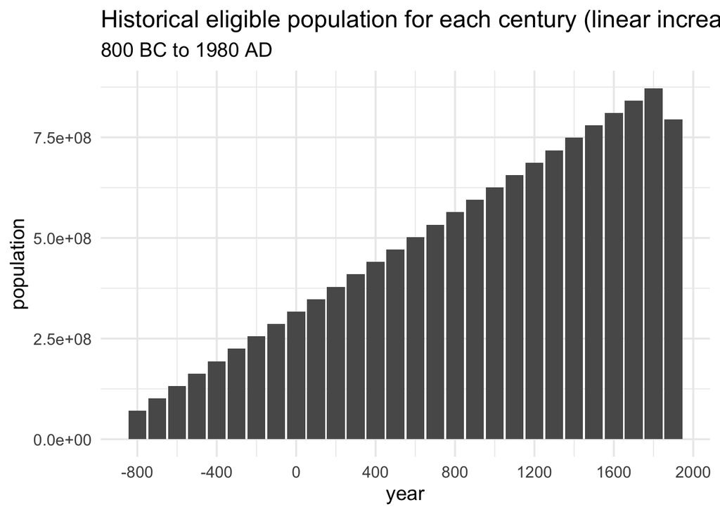

```r
cum_prop_population_linear = cumsum(Epop_generations_linear) / sum(Epop_generations_linear)
gen_stats_linear = data.frame(
  gen_start = generations,
  gen_end = c(generations[-1] -1, 1980),
  gen_pop = Epop_generations_linear,
  cum_prop_population = cum_prop_population_linear,
  n = sapply(hpi_generations, nrow)
)

ggplot(gen_stats_linear) +
  aes(x = gen_start, y = gen_pop) +
  geom_bar(stat = "identity") +
  scale_x_continuous(breaks = seq(-800, 2000, by = 400)) +
  theme_minimal(base_size = 14) +
  labs(x = "year", y = "population",
       title ="Historical eligible population for each century (linear increase)",
       subtitle = "800 BC to 1980 AD")
```

We now compute latent talent estimates using Full House Modeling with respect to this alternate historic eligible population.

```r
system.time({
  hpi_adjust_vs_peers_linear =
    do.call(rbind,
            mclapply(seq_along(hpi_generations),
                     mc.cores = nCores, function(j){
                       cbind(hpi_generations[[j]],
                             "hpi_talent" =
                               talent_computing_nonpara(ystar = as.numeric(ystar_mat[j, 1]),
                                                        y = hpi_generations[[j]] %>% pull(hpi),
                                                        npop = Epop_generations_linear[[j]]))
                     })) %>% arrange(desc(hpi_talent))
})
```

```
##     user   system  elapsed
## 1014.264    8.766  956.960
```

Here is the top 50 list of the most impactful people in history ranked by estimated latent talent obtained via Full House Modeling with respect to this alternate historic eligible population.

```r
kable(hpi_adjust_vs_peers_linear %>% as.data.frame() %>% head(50),
      format = "html") %>%
  kable_styling(full_width = FALSE, position = "left") %>%
  scroll_box(width = "100%")
```

| name | occupation | birthyear | gender | bplace_country | hpi | hpi_talent |
| --- | --- | --- | --- | --- | --- | --- |
| Leonardo da Vinci | INVENTOR | 1452 | M | Italy | 97.46069 | 6.128786 |
| Ragnar Lodbrok | NOBLEMAN | 850 | M | United Kingdom | 89.20628 | 6.068371 |
| Adolf Hitler | POLITICIAN | 1889 | M | Austria | 95.48942 | 6.053903 |
| Galileo Galilei | ASTRONOMER | 1564 | M | Italy | 95.34711 | 6.023810 |
| Avicenna | PHILOSOPHER | 980 | M | Uzbekistan | 92.50853 | 6.012359 |
| Omar Khayyam | MATHEMATICIAN | 1048 | M | Iran | 87.49654 | 6.010705 |
| Genghis Khan | MILITARY PERSONNEL | 1162 | M | Mongolia | 97.72367 | 6.008078 |
| Johannes Gutenberg | INVENTOR | 1394 | M | Germany | 92.44853 | 6.005162 |
| Isaac Newton | PHYSICIST | 1643 | M | United Kingdom | 96.83657 | 5.999936 |
| Ali | RELIGIOUS FIGURE | 601 | M | Saudi Arabia | 87.27485 | 5.997195 |
| Marco Polo | EXPLORER | 1254 | M | Italy | 95.22918 | 5.984703 |
| Ludwig van Beethoven | COMPOSER | 1770 | M | Germany | 96.58397 | 5.977747 |
| Muhammad | RELIGIOUS FIGURE | 570 | M | Saudi Arabia | 100.00000 | 5.964443 |
| Che Guevara | SOCIAL ACTIVIST | 1928 | M | Argentina | 93.40716 | 5.963232 |
| Charlemagne | POLITICIAN | 748 | M | France | 91.86112 | 5.961607 |
| Augustine of Hippo | PHILOSOPHER | 354 | M | Algeria | 90.32378 | 5.925382 |
| Elizabeth II | NOBLEMAN | 1926 | F | United Kingdom | 93.04777 | 5.925341 |
| Albert Einstein | PHYSICIST | 1879 | M | Germany | 94.79355 | 5.922415 |
| William Shakespeare | WRITER | 1564 | M | United Kingdom | 94.54765 | 5.913287 |
| Attila | POLITICIAN | 406 | M | Hungary | 90.29251 | 5.911928 |
| Constantine the Great | POLITICIAN | 272 | M | Serbia | 90.75638 | 5.905828 |
| Johann Sebastian Bach | COMPOSER | 1685 | M | Germany | 94.83113 | 5.888615 |
| Timur | MILITARY PERSONNEL | 1336 | M | Uzbekistan | 90.59327 | 5.883478 |
| Dante Alighieri | WRITER | 1265 | M | Italy | 92.90618 | 5.877041 |
| Jesus | RELIGIOUS FIGURE | -4 | M | Israel | 95.52158 | 5.870987 |
| Napoleon | POLITICIAN | 1769 | M | France | 95.87986 | 5.863086 |
| Wolfgang Amadeus Mozart | COMPOSER | 1756 | M | Austria | 95.81115 | 5.853491 |
| Michelangelo | PAINTER | 1475 | M | Italy | 94.64203 | 5.844998 |
| Al-Ghazali | PHILOSOPHER | 1058 | M | Iran | 85.22429 | 5.843884 |
| Saladin | POLITICIAN | 1138 | M | Iraq | 90.87401 | 5.837817 |
| Julius Caesar | POLITICIAN | -100 | M | Italy | 95.84403 | 5.831742 |
| Commodus | POLITICIAN | 161 | M | Italy | 89.25164 | 5.831240 |
| Justinian I | POLITICIAN | 482 | M | North Macedonia | 88.45062 | 5.815329 |
| Archimedes | MATHEMATICIAN | -287 | M | Italy | 93.92727 | 5.812333 |
| Louis XIV of France | POLITICIAN | 1638 | M | France | 93.36695 | 5.812119 |
| Muhammad ibn Musa al-Khwarizmi | MATHEMATICIAN | 780 | M | Turkmenistan | 87.34336 | 5.808912 |
| René Descartes | PHILOSOPHER | 1596 | M | France | 92.74489 | 5.805915 |
| Ivar the Boneless | POLITICIAN | 900 | M | Denmark | 85.46084 | 5.805265 |
| Sigmund Freud | PSYCHOLOGIST | 1856 | M | Czechia | 93.67498 | 5.797284 |
| Harald Fairhair | POLITICIAN | 850 | M | Norway | 84.92352 | 5.796020 |
| Charles Martel | MILITARY PERSONNEL | 688 | M | Belgium | 85.01482 | 5.787037 |
| Thomas Aquinas | PHILOSOPHER | 1225 | M | Italy | 89.88498 | 5.786137 |
| Vincent van Gogh | PAINTER | 1853 | M | Netherlands | 93.60249 | 5.783635 |
| Martin Luther | RELIGIOUS FIGURE | 1483 | M | Germany | 94.31473 | 5.778667 |
| Pope Francis | RELIGIOUS FIGURE | 1936 | M | Argentina | 91.89196 | 5.778622 |
| Hannibal | POLITICIAN | -183 | M | Tunisia | 90.14302 | 5.778047 |
| Nelson Mandela | SOCIAL ACTIVIST | 1918 | M | South Africa | 91.88008 | 5.776650 |
| Umar | POLITICIAN | 585 | M | Saudi Arabia | 89.18275 | 5.774957 |
| Francis of Assisi | RELIGIOUS FIGURE | 1182 | M | Italy | 88.40271 | 5.770357 |
| Petrarch | WRITER | 1304 | M | Italy | 88.24960 | 5.770086 |

This top 50 list has 40 names in common with the original list with centuries used to designate eras, suggesting respectable sensitivity.

```r
common =
  intersect(hpi_adjust_vs_peers_linear %>% as.data.frame() %>% head(50) %>% pull(name),
            hpi_adjust_vs_peers %>% as.data.frame() %>% head(50) %>% pull(name))
length(common)
```

```
## [1] 40
```

Back to topics

## Flat Increase in Eligible Population

Here we investigate how the historic rankings change when the historic eligible population exhibits a linear increase, but is mostly flat, instead of an exponential increase as originally calculated.

```r
Epop_generations_flat = Epop_generations[1] + 1000000 * 0:(n_gen-1)
```

This alternate historic eligible population is displayed below.

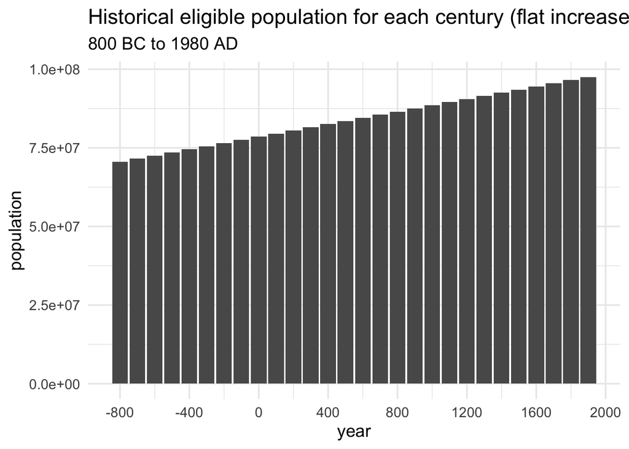

```r
cum_prop_population_flat = cumsum(Epop_generations_flat) / sum(Epop_generations_flat)
gen_stats_flat = data.frame(
  gen_start = generations,
  gen_end = c(generations[-1] -1, 1980),
  gen_pop = Epop_generations_flat,
  cum_prop_population = cum_prop_population_flat,
  n = sapply(hpi_generations, nrow)
)

ggplot(gen_stats_flat) +
  aes(x = gen_start, y = gen_pop) +
  geom_bar(stat = "identity") +
  scale_x_continuous(breaks = seq(-800, 2000, by = 400)) +
  theme_minimal(base_size = 14) +
  labs(x = "year", y = "population",
       title ="Historical eligible population for each century (flat increase)",
       subtitle = "800 BC to 1980 AD")
```

We now compute latent talent estimates using Full House Modeling with respect to this alternate historic eligible population.

```r
system.time({
  hpi_adjust_vs_peers_flat =
    do.call(rbind,
            mclapply(seq_along(hpi_generations),
                     mc.cores = nCores, function(j){
                       cbind(hpi_generations[[j]],
                             "hpi_talent" =
                               talent_computing_nonpara(ystar = as.numeric(ystar_mat[j, 1]),
                                                        y = hpi_generations[[j]] %>% pull(hpi),
                                                        npop = Epop_generations_flat[[j]]))
                     })) %>% arrange(desc(hpi_talent))
})
```

```
##     user   system  elapsed
## 1014.136    8.885  956.081
```

Here is the top 50 list of the most impactful people in history ranked by estimated latent talent obtained via Full House Modeling with respect to this alternate historic eligible population.

```r
kable(hpi_adjust_vs_peers_flat %>% as.data.frame() %>% head(50),
      format = "html") %>%
  kable_styling(full_width = FALSE, position = "left") %>%
  scroll_box(width = "100%")
```

| name | occupation | birthyear | gender | bplace_country | hpi | hpi_talent |
| --- | --- | --- | --- | --- | --- | --- |
| Leonardo da Vinci | INVENTOR | 1452 | M | Italy | 97.46069 | 5.786968 |
| Ragnar Lodbrok | NOBLEMAN | 850 | M | United Kingdom | 89.20628 | 5.759822 |
| Ali | RELIGIOUS FIGURE | 601 | M | Saudi Arabia | 87.27485 | 5.700763 |
| Avicenna | PHILOSOPHER | 980 | M | Uzbekistan | 92.50853 | 5.693817 |
| Adolf Hitler | POLITICIAN | 1889 | M | Austria | 95.48942 | 5.689054 |
| Omar Khayyam | MATHEMATICIAN | 1048 | M | Iran | 87.49654 | 5.685383 |
| Genghis Khan | MILITARY PERSONNEL | 1162 | M | Mongolia | 97.72367 | 5.676304 |
| Muhammad | RELIGIOUS FIGURE | 570 | M | Saudi Arabia | 100.00000 | 5.675205 |
| Galileo Galilei | ASTRONOMER | 1564 | M | Italy | 95.34711 | 5.670936 |
| Homer | WRITER | -800 | M | Turkey | 92.32471 | 5.662651 |
| Johannes Gutenberg | INVENTOR | 1394 | M | Germany | 92.44853 | 5.661622 |
| Charlemagne | POLITICIAN | 748 | M | France | 91.86112 | 5.655204 |
| Augustine of Hippo | PHILOSOPHER | 354 | M | Algeria | 90.32378 | 5.654203 |
| Marco Polo | EXPLORER | 1254 | M | Italy | 95.22918 | 5.645647 |
| Constantine the Great | POLITICIAN | 272 | M | Serbia | 90.75638 | 5.645106 |
| Isaac Newton | PHYSICIST | 1643 | M | United Kingdom | 96.83657 | 5.640805 |
| Jesus | RELIGIOUS FIGURE | -4 | M | Israel | 95.52158 | 5.635074 |
| Attila | POLITICIAN | 406 | M | Hungary | 90.29251 | 5.629733 |
| Archimedes | MATHEMATICIAN | -287 | M | Italy | 93.92727 | 5.627083 |
| Ludwig van Beethoven | COMPOSER | 1770 | M | Germany | 96.58397 | 5.612637 |
| Che Guevara | SOCIAL ACTIVIST | 1928 | M | Argentina | 93.40716 | 5.610866 |
| Julius Caesar | POLITICIAN | -100 | M | Italy | 95.84403 | 5.609764 |
| Aesop | WRITER | -620 | M | Bulgaria | 88.17256 | 5.608802 |
| Alexander the Great | MILITARY PERSONNEL | -356 | M | Greece | 96.42753 | 5.604698 |
| Commodus | POLITICIAN | 161 | M | Italy | 89.25164 | 5.579822 |
| Hannibal | POLITICIAN | -183 | M | Tunisia | 90.14302 | 5.571650 |
| Elizabeth II | NOBLEMAN | 1926 | F | United Kingdom | 93.04777 | 5.570709 |
| Plato | PHILOSOPHER | -427 | M | Greece | 95.73000 | 5.568332 |
| Confucius | PHILOSOPHER | -551 | M | China | 93.64056 | 5.568182 |
| William Shakespeare | WRITER | 1564 | M | United Kingdom | 94.54765 | 5.553777 |
| Aristotle | PHILOSOPHER | -384 | M | Greece | 96.05759 | 5.553079 |
| Albert Einstein | PHYSICIST | 1879 | M | Germany | 94.79355 | 5.549397 |
| Gautama Buddha | PHILOSOPHER | -566 | M | Nepal | 93.46825 | 5.548289 |
| Socrates | PHILOSOPHER | -470 | M | Greece | 95.15967 | 5.538954 |
| Timur | MILITARY PERSONNEL | 1336 | M | Uzbekistan | 90.59327 | 5.532801 |
| Dante Alighieri | WRITER | 1265 | M | Italy | 92.90618 | 5.531751 |
| Justinian I | POLITICIAN | 482 | M | North Macedonia | 88.45062 | 5.528477 |
| Johann Sebastian Bach | COMPOSER | 1685 | M | Germany | 94.83113 | 5.522647 |
| Al-Ghazali | PHILOSOPHER | 1058 | M | Iran | 85.22429 | 5.509261 |
| Saladin | POLITICIAN | 1138 | M | Iraq | 90.87401 | 5.496342 |
| Muhammad ibn Musa al-Khwarizmi | MATHEMATICIAN | 780 | M | Turkmenistan | 87.34336 | 5.494471 |
| Napoleon | POLITICIAN | 1769 | M | France | 95.87986 | 5.490779 |
| Michelangelo | PAINTER | 1475 | M | Italy | 94.64203 | 5.486494 |
| Saint George | RELIGIOUS FIGURE | 280 | M | Turkey | 88.40714 | 5.485486 |
| Thales of Miletus | PHILOSOPHER | -623 | M | Turkey | 87.50063 | 5.481072 |
| Wolfgang Amadeus Mozart | COMPOSER | 1756 | M | Austria | 95.81115 | 5.480570 |
| Charles Martel | MILITARY PERSONNEL | 688 | M | Belgium | 85.01482 | 5.479879 |
| Umar | POLITICIAN | 585 | M | Saudi Arabia | 89.18275 | 5.476277 |
| Ivar the Boneless | POLITICIAN | 900 | M | Denmark | 85.46084 | 5.475356 |
| Harald Fairhair | POLITICIAN | 850 | M | Norway | 84.92352 | 5.472984 |

This top 50 list has 31 names in common with the original list with centuries used to designate eras, which is fewer than a linear increase as to be expected.

```r
common =
  intersect(hpi_adjust_vs_peers_flat %>% as.data.frame() %>% head(50) %>% pull(name),
            hpi_adjust_vs_peers %>% as.data.frame() %>% head(50) %>% pull(name))
length(common)
```

```
## [1] 31
```

Back to topics